# ANCOVA in Vocabulario (Vocabulario)

Geiser C. Challco geiser@alumni.usp.br

- Descriptive Statistics of Initial Data
- ANCOVA and Pairwise for one factor: **grupo**
  - Without remove non-normal data
  - Computing ANCOVA and PairWise After removing non-normal data (OK)
    - Plots for ancova
    - Checking linearity assumption
    - Checking normality and homogeneity
- ANCOVA and Pairwise for two factors **grupo:Sexo**
  - Without remove non-normal data
  - Computing ANCOVA and PairWise After removing non-normal data (OK)
    - Plots for ancova
    - Checking linearity assumption
    - Checking normality and homogeneity
- ANCOVA and Pairwise for two factors **grupo:Zona**
  - Without remove non-normal data
  - Computing ANCOVA and PairWise After removing non-normal data (OK)
    - Plots for ancova
    - Checking linearity assumption
    - Checking normality and homogeneity
- ANCOVA and Pairwise for two factors **grupo:Cor.Raca**
  - Without remove non-normal data
  - Computing ANCOVA and PairWise After removing non-normal data (OK)
    - Plots for ancova
    - Checking linearity assumption
    - Checking normality and homogeneity
- ANCOVA and Pairwise for two factors **grupo:vocab.quintile**
  - Without remove non-normal data
  - Computing ANCOVA and PairWise After removing non-normal data (OK)
    - Plots for ancova
    - Checking linearity assumption
    - Checking normality and homogeneity
- Summary of Results
  - Descriptive Statistics
  - ANCOVA Table Comparison
  - PairWise Table Comparison
  - EMMS Table Comparison

**NOTE**:

- Teste ANCOVA para determinar se houve diferenças significativas no Vocabulario (medido usando pre- e pos-testes).
- ANCOVA test to determine whether there were significant differences in Vocabulario (measured using pre- and post-tests).

# Descriptive Statistics of Initial Data

```r
df <- get.descriptives(dat, c(dv.pre, dv.pos), c("grupo"),
                       include.global = T, symmetry.test = T, normality.test = F)
df <- plyr::rbind.fill(
  df, do.call(plyr::rbind.fill, lapply(lfatores2, FUN = function(f) {
    if (nrow(dat) > 0 && sum(!is.na(unique(dat[[f]]))) > 1)
      get.descriptives(dat, c(dv.pre,dv.pos), c("grupo", f),
                       symmetry.test = T, normality.test = F)
    }))
)
(df <- df[,c(fatores1[fatores1 %in% colnames(df)],"variable",
             colnames(df)[!colnames(df) %in% c(fatores1,"variable")])])
```

```
##           grupo Sexo   Zona Cor.Raca vocab.quintile  variable   n   mean median min max     sd    se      ci
## 1      Controle <NA>   <NA>     <NA>           <NA> vocab.pre 152 24.480   25.0   5  45  8.755 0.710   1.403
## 2  Experimental <NA>   <NA>     <NA>           <NA> vocab.pre 197 26.518   27.0   1  43  8.287 0.590   1.164
## 3          <NA> <NA>   <NA>     <NA>           <NA> vocab.pre 349 25.630   26.0   1  45  8.542 0.457   0.899
## 4      Controle <NA>   <NA>     <NA>           <NA> vocab.pos 152 26.132   27.0   7  45  8.827 0.716   1.415
## 5  Experimental <NA>   <NA>     <NA>           <NA> vocab.pos 197 26.817   27.0   5  46  8.540 0.608   1.200
## 6          <NA> <NA>   <NA>     <NA>           <NA> vocab.pos 349 26.519   27.0   5  46  8.660 0.464   0.912
## 7      Controle    F   <NA>     <NA>           <NA> vocab.pre  85 25.718   26.0   8  42  8.185 0.888   1.765
## 8      Controle    M   <NA>     <NA>           <NA> vocab.pre  67 22.910   21.0   5  45  9.254 1.131   2.257
## 9  Experimental    F   <NA>     <NA>           <NA> vocab.pre  99 26.202   27.0   1  43  8.281 0.832   1.652
## 10 Experimental    M   <NA>     <NA>           <NA> vocab.pre  98 26.837   27.0   5  43  8.323 0.841   1.669
## 11     Controle    F   <NA>     <NA>           <NA> vocab.pos  85 27.365   28.0   7  43  8.021 0.870   1.730
## 12     Controle    M   <NA>     <NA>           <NA> vocab.pos  67 24.567   24.0   7  45  9.589 1.171   2.339
## 13 Experimental    F   <NA>     <NA>           <NA> vocab.pos  99 27.677   28.0   7  46  7.869 0.791   1.569
## 14 Experimental    M   <NA>     <NA>           <NA> vocab.pos  98 25.949   26.0   5  44  9.127 0.922   1.830
```

[output cut: 98 more lines]

| grupo | Sexo | Zona | Cor.Raca | vocab.quintile | variable | n | mean | median | min | max | sd | se | ci | iqr | symmetry | skewness | kurtosis |
| --- | --- | --- | --- | --- | --- | --- | --- | --- | --- | --- | --- | --- | --- | --- | --- | --- | --- |
| Controle |  |  |  |  | vocab.pre | 152 | 24.480 | 25.0 | 5 | 45 | 8.755 | 0.710 | 1.403 | 13.25 | YES | -0.005 | -0.831 |
| Experimental |  |  |  |  | vocab.pre | 197 | 26.518 | 27.0 | 1 | 43 | 8.287 | 0.590 | 1.164 | 13.00 | YES | -0.203 | -0.492 |
|  |  |  |  |  | vocab.pre | 349 | 25.630 | 26.0 | 1 | 45 | 8.542 | 0.457 | 0.899 | 13.00 | YES | -0.127 | -0.662 |
| Controle |  |  |  |  | vocab.pos | 152 | 26.132 | 27.0 | 7 | 45 | 8.827 | 0.716 | 1.415 | 14.00 | YES | -0.147 | -0.894 |
| Experimental |  |  |  |  | vocab.pos | 197 | 26.817 | 27.0 | 5 | 46 | 8.540 | 0.608 | 1.200 | 12.00 | YES | -0.293 | -0.467 |
|  |  |  |  |  | vocab.pos | 349 | 26.519 | 27.0 | 5 | 46 | 8.660 | 0.464 | 0.912 | 13.00 | YES | -0.230 | -0.659 |
| Controle | F |  |  |  | vocab.pre | 85 | 25.718 | 26.0 | 8 | 42 | 8.185 | 0.888 | 1.765 | 14.00 | YES | -0.096 | -0.909 |
| Controle | M |  |  |  | vocab.pre | 67 | 22.910 | 21.0 | 5 | 45 | 9.254 | 1.131 | 2.257 | 15.00 | YES | 0.184 | -0.788 |
| Experimental | F |  |  |  | vocab.pre | 99 | 26.202 | 27.0 | 1 | 43 | 8.281 | 0.832 | 1.652 | 12.00 | YES | -0.145 | -0.340 |
| Experimental | M |  |  |  | vocab.pre | 98 | 26.837 | 27.0 | 5 | 43 | 8.323 | 0.841 | 1.669 | 12.00 | YES | -0.260 | -0.679 |
| Controle | F |  |  |  | vocab.pos | 85 | 27.365 | 28.0 | 7 | 43 | 8.021 | 0.870 | 1.730 | 12.00 | YES | -0.267 | -0.717 |
| Controle | M |  |  |  | vocab.pos | 67 | 24.567 | 24.0 | 7 | 45 | 9.589 | 1.171 | 2.339 | 15.50 | YES | 0.084 | -1.076 |
| Experimental | F |  |  |  | vocab.pos | 99 | 27.677 | 28.0 | 7 | 46 | 7.869 | 0.791 | 1.569 | 9.50 | YES | -0.409 | -0.100 |
| Experimental | M |  |  |  | vocab.pos | 98 | 25.949 | 26.0 | 5 | 44 | 9.127 | 0.922 | 1.830 | 14.50 | YES | -0.145 | -0.764 |
| Controle |  | Rural |  |  | vocab.pre | 77 | 25.065 | 26.0 | 8 | 45 | 8.565 | 0.976 | 1.944 | 14.00 | YES | 0.046 | -0.954 |
| Controle |  | Urbana |  |  | vocab.pre | 50 | 25.980 | 25.0 | 6 | 42 | 8.625 | 1.220 | 2.451 | 13.50 | YES | -0.231 | -0.808 |
| Controle |  |  |  |  | vocab.pre | 25 | 19.680 | 19.0 | 5 | 40 | 8.265 | 1.653 | 3.412 | 11.00 | YES | 0.330 | -0.338 |
| Experimental |  | Rural |  |  | vocab.pre | 92 | 26.630 | 27.0 | 5 | 43 | 8.513 | 0.888 | 1.763 | 11.50 | YES | -0.205 | -0.635 |
| Experimental |  | Urbana |  |  | vocab.pre | 76 | 26.842 | 27.0 | 1 | 43 | 8.201 | 0.941 | 1.874 | 12.00 | YES | -0.289 | -0.085 |
| Experimental |  |  |  |  | vocab.pre | 29 | 25.310 | 25.0 | 13 | 37 | 7.947 | 1.476 | 3.023 | 13.00 | YES | 0.015 | -1.382 |
| Controle |  | Rural |  |  | vocab.pos | 77 | 27.104 | 28.0 | 10 | 45 | 8.637 | 0.984 | 1.960 | 14.00 | YES | -0.144 | -0.925 |
| Controle |  | Urbana |  |  | vocab.pos | 50 | 26.680 | 28.5 | 7 | 40 | 9.041 | 1.279 | 2.569 | 12.75 | YES | -0.495 | -0.784 |
| Controle |  |  |  |  | vocab.pos | 25 | 22.040 | 20.0 | 9 | 42 | 8.126 | 1.625 | 3.354 | 10.00 | NO | 0.599 | -0.176 |
| Experimental |  | Rural |  |  | vocab.pos | 92 | 26.587 | 27.0 | 5 | 46 | 8.765 | 0.914 | 1.815 | 12.00 | YES | -0.196 | -0.340 |
| Experimental |  | Urbana |  |  | vocab.pos | 76 | 27.566 | 29.0 | 8 | 44 | 8.385 | 0.962 | 1.916 | 12.00 | YES | -0.413 | -0.612 |
| Experimental |  |  |  |  | vocab.pos | 29 | 25.586 | 26.0 | 7 | 37 | 8.326 | 1.546 | 3.167 | 14.00 | YES | -0.309 | -0.890 |
| Controle |  |  | Branca |  | vocab.pre | 22 | 26.273 | 27.0 | 12 | 45 | 8.172 | 1.742 | 3.623 | 11.75 | YES | 0.214 | -0.552 |
| Controle |  |  | Indígena |  | vocab.pre | 8 | 24.250 | 25.5 | 15 | 33 | 6.386 | 2.258 | 5.339 | 5.75 | YES | -0.367 | -1.412 |
| Controle |  |  | Parda |  | vocab.pre | 44 | 22.591 | 21.0 | 9 | 38 | 8.478 | 1.278 | 2.578 | 15.25 | YES | 0.286 | -1.148 |
| Controle |  |  |  |  | vocab.pre | 78 | 25.064 | 25.5 | 5 | 42 | 9.217 | 1.044 | 2.078 | 13.00 | YES | -0.182 | -0.847 |
| Experimental |  |  | Branca |  | vocab.pre | 12 | 26.667 | 27.5 | 15 | 37 | 6.972 | 2.013 | 4.430 | 8.75 | YES | -0.364 | -1.222 |
| Experimental |  |  | Indígena |  | vocab.pre | 2 | 24.000 | 24.0 | 16 | 32 | 11.314 | 8.000 | 101.650 | 8.00 | few data | 0.000 | 0.000 |
| Experimental |  |  | Parda |  | vocab.pre | 53 | 24.396 | 25.0 | 1 | 42 | 8.654 | 1.189 | 2.385 | 12.00 | YES | -0.038 | -0.377 |
| Experimental |  |  |  |  | vocab.pre | 130 | 27.408 | 27.5 | 5 | 43 | 8.140 | 0.714 | 1.413 | 11.75 | YES | -0.241 | -0.567 |
| Controle |  |  | Branca |  | vocab.pos | 22 | 28.000 | 29.0 | 13 | 45 | 7.910 | 1.686 | 3.507 | 10.00 | YES | 0.109 | -0.601 |
| Controle |  |  | Indígena |  | vocab.pos | 8 | 28.875 | 27.5 | 18 | 38 | 7.717 | 2.728 | 6.452 | 12.50 | YES | 0.011 | -1.784 |
| Controle |  |  | Parda |  | vocab.pos | 44 | 25.545 | 26.0 | 7 | 40 | 9.598 | 1.447 | 2.918 | 16.50 | YES | -0.082 | -1.330 |
| Controle |  |  |  |  | vocab.pos | 78 | 25.654 | 25.5 | 7 | 43 | 8.756 | 0.991 | 1.974 | 13.00 | YES | -0.173 | -0.860 |
| Experimental |  |  | Branca |  | vocab.pos | 12 | 24.000 | 23.0 | 9 | 37 | 7.160 | 2.067 | 4.550 | 6.75 | YES | -0.110 | -0.238 |
| Experimental |  |  | Indígena |  | vocab.pos | 2 | 26.500 | 26.5 | 18 | 35 | 12.021 | 8.500 | 108.003 | 8.50 | few data | 0.000 | 0.000 |
| Experimental |  |  | Parda |  | vocab.pos | 53 | 25.396 | 26.0 | 7 | 40 | 7.510 | 1.032 | 2.070 | 9.00 | YES | -0.224 | -0.334 |
| Experimental |  |  |  |  | vocab.pos | 130 | 27.662 | 29.0 | 5 | 46 | 8.961 | 0.786 | 1.555 | 12.00 | YES | -0.416 | -0.499 |
| Controle |  |  |  | 1st quintile | vocab.pre | 32 | 12.500 | 13.5 | 5 | 16 | 3.059 | 0.541 | 1.103 | 4.00 | NO | -0.894 | -0.314 |
| Controle |  |  |  | 2nd quintile | vocab.pre | 35 | 19.686 | 20.0 | 17 | 22 | 1.510 | 0.255 | 0.519 | 2.00 | YES | -0.123 | -1.132 |
| Controle |  |  |  | 3rd quintile | vocab.pre | 39 | 26.256 | 26.0 | 23 | 29 | 1.846 | 0.296 | 0.598 | 2.50 | YES | -0.001 | -1.044 |
| Controle |  |  |  | 4th quintile | vocab.pre | 23 | 32.261 | 32.0 | 30 | 34 | 1.544 | 0.322 | 0.668 | 3.00 | YES | -0.135 | -1.558 |
| Controle |  |  |  | 5th quintile | vocab.pre | 23 | 37.652 | 37.0 | 35 | 45 | 2.347 | 0.489 | 1.015 | 1.50 | NO | 1.410 | 2.080 |
| Experimental |  |  |  | 1st quintile | vocab.pre | 30 | 13.533 | 14.0 | 1 | 16 | 3.401 | 0.621 | 1.270 | 3.00 | NO | -2.219 | 4.794 |
| Experimental |  |  |  | 2nd quintile | vocab.pre | 34 | 19.824 | 20.0 | 17 | 22 | 1.642 | 0.282 | 0.573 | 3.00 | YES | -0.244 | -1.302 |
| Experimental |  |  |  | 3rd quintile | vocab.pre | 54 | 26.093 | 26.0 | 23 | 29 | 1.730 | 0.235 | 0.472 | 2.00 | YES | -0.054 | -0.888 |
| Experimental |  |  |  | 4th quintile | vocab.pre | 44 | 31.750 | 32.0 | 30 | 34 | 1.512 | 0.228 | 0.460 | 3.00 | YES | 0.101 | -1.505 |
| Experimental |  |  |  | 5th quintile | vocab.pre | 35 | 38.229 | 37.0 | 35 | 43 | 2.315 | 0.391 | 0.795 | 2.50 | NO | 0.739 | -0.765 |
| Controle |  |  |  | 1st quintile | vocab.pos | 32 | 16.594 | 16.5 | 7 | 26 | 4.983 | 0.881 | 1.797 | 7.00 | YES | -0.002 | -0.897 |
| Controle |  |  |  | 2nd quintile | vocab.pos | 35 | 22.057 | 21.0 | 11 | 36 | 6.097 | 1.031 | 2.094 | 8.00 | YES | 0.223 | -0.692 |
| Controle |  |  |  | 3rd quintile | vocab.pos | 39 | 27.410 | 28.0 | 7 | 38 | 5.798 | 0.928 | 1.879 | 7.00 | NO | -0.973 | 2.042 |
| Controle |  |  |  | 4th quintile | vocab.pos | 23 | 34.435 | 34.0 | 27 | 41 | 3.678 | 0.767 | 1.591 | 5.00 | YES | 0.082 | -1.027 |
| Controle |  |  |  | 5th quintile | vocab.pos | 23 | 35.130 | 37.0 | 11 | 45 | 7.238 | 1.509 | 3.130 | 4.50 | NO | -1.792 | 3.480 |
| Experimental |  |  |  | 1st quintile | vocab.pos | 30 | 16.900 | 18.0 | 5 | 29 | 6.326 | 1.155 | 2.362 | 10.00 | YES | 0.013 | -1.022 |
| Experimental |  |  |  | 2nd quintile | vocab.pos | 34 | 20.706 | 21.0 | 8 | 34 | 5.808 | 0.996 | 2.026 | 8.00 | YES | -0.083 | -0.429 |
| Experimental |  |  |  | 3rd quintile | vocab.pos | 54 | 27.074 | 27.0 | 7 | 37 | 5.987 | 0.815 | 1.634 | 6.00 | NO | -0.740 | 0.945 |
| Experimental |  |  |  | 4th quintile | vocab.pos | 44 | 30.750 | 31.0 | 15 | 40 | 5.109 | 0.770 | 1.553 | 7.00 | NO | -0.535 | 0.468 |
| Experimental |  |  |  | 5th quintile | vocab.pos | 35 | 35.914 | 37.0 | 17 | 46 | 5.938 | 1.004 | 2.040 | 4.50 | NO | -1.130 | 1.821 |

# ANCOVA and Pairwise for one factor: **grupo**

## Without remove non-normal data

```r
pdat = remove_group_data(dat[!is.na(dat[["grupo"]]),], "vocab.pos", "grupo")

pdat.long <- rbind(pdat[,c("id","grupo")], pdat[,c("id","grupo")])
pdat.long[["time"]] <- c(rep("pre", nrow(pdat)), rep("pos", nrow(pdat)))
pdat.long[["time"]] <- factor(pdat.long[["time"]], c("pre","pos"))
pdat.long[["vocab"]] <- c(pdat[["vocab.pre"]], pdat[["vocab.pos"]])

aov = anova_test(pdat, vocab.pos ~ vocab.pre + grupo)
laov[["grupo"]] <- get_anova_table(aov)
```

```r
pwc <- emmeans_test(pdat, vocab.pos ~ grupo, covariate = vocab.pre,
                    p.adjust.method = "bonferroni")
```

```r
pwc.long <- emmeans_test(dplyr::group_by_at(pdat.long, "grupo"),
                          vocab ~ time,
                          p.adjust.method = "bonferroni")
lpwc[["grupo"]] <- plyr::rbind.fill(pwc, pwc.long)
```

```r
ds <- get.descriptives(pdat, "vocab.pos", "grupo", covar = "vocab.pre")
ds <- merge(ds[ds$variable != "vocab.pre",],
            ds[ds$variable == "vocab.pre", !colnames(ds) %in% c("variable")],
            by = "grupo", all.x = T, suffixes = c("", ".vocab.pre"))
ds <- merge(get_emmeans(pwc), ds, by = "grupo", suffixes = c(".emms", ""))
ds <- ds[,c("grupo","n","mean.vocab.pre","se.vocab.pre","mean","se","emmean","se.emms")]

colnames(ds) <- c("grupo", "N", paste0(c("M","SE")," (pre)"),
                  paste0(c("M","SE"), " (unadj)"), paste0(c("M", "SE"), " (adj)"))

lemms[["grupo"]] <- ds
```

## Computing ANCOVA and PairWise After removing non-normal data (OK)

```r
wdat = pdat

res = residuals(lm(vocab.pos ~ vocab.pre + grupo, data = wdat))
non.normal = getNonNormal(res, wdat$id, plimit = 0.05)

wdat = wdat[!wdat$id %in% non.normal,]

wdat.long <- rbind(wdat[,c("id","grupo")], wdat[,c("id","grupo")])
wdat.long[["time"]] <- c(rep("pre", nrow(wdat)), rep("pos", nrow(wdat)))
wdat.long[["time"]] <- factor(wdat.long[["time"]], c("pre","pos"))
wdat.long[["vocab"]] <- c(wdat[["vocab.pre"]], wdat[["vocab.pos"]])

ldat[["grupo"]] = wdat

(non.normal)
```

```
## [1] "P983"  "P1966" "P3042" "P1936" "P976"  "P1961"
```

```r
aov = anova_test(wdat, vocab.pos ~ vocab.pre + grupo)
laov[["grupo"]] <- merge(get_anova_table(aov), laov[["grupo"]], by="Effect", suffixes = c("","'"))

(df = get_anova_table(aov))
```

```
## ANOVA Table (type II tests)
##
##      Effect DFn DFd       F        p p<.05   ges
## 1 vocab.pre   1 340 652.429 4.35e-81     * 0.657
## 2     grupo   1 340   4.221 4.10e-02     * 0.012
```

| Effect | DFn | DFd | F | p | p<.05 | ges |
| --- | --- | --- | --- | --- | --- | --- |
| vocab.pre | 1 | 340 | 652.429 | 0.000 | * | 0.657 |
| grupo | 1 | 340 | 4.221 | 0.041 | * | 0.012 |

[output not shown]

```r
pwc.long <- emmeans_test(dplyr::group_by_at(wdat.long, "grupo"),
                         vocab ~ time,
                         p.adjust.method = "bonferroni")
lpwc[["grupo"]] <- merge(plyr::rbind.fill(pwc, pwc.long), lpwc[["grupo"]], by=c("grupo","term",".y.","group1","group2"), suffixes = c("","'"))
```

| grupo | term | .y. | group1 | group2 | df | statistic | p | p.adj | p.adj.signif |
| --- | --- | --- | --- | --- | --- | --- | --- | --- | --- |
| Controle | time | vocab | pre | pos | 682 | -2.139 | 0.033 | 0.033 | * |
| Experimental | time | vocab | pre | pos | 682 | -0.659 | 0.510 | 0.510 | ns |

```r
ds <- get.descriptives(wdat, "vocab.pos", "grupo", covar = "vocab.pre")
ds <- merge(ds[ds$variable != "vocab.pre",],
            ds[ds$variable == "vocab.pre", !colnames(ds) %in% c("variable")],
            by = "grupo", all.x = T, suffixes = c("", ".vocab.pre"))
ds <- merge(get_emmeans(pwc), ds, by = "grupo", suffixes = c(".emms", ""))
ds <- ds[,c("grupo","n","mean.vocab.pre","se.vocab.pre","mean","se","emmean","se.emms")]

colnames(ds) <- c("grupo", "N", paste0(c("M","SE")," (pre)"),
                  paste0(c("M","SE"), " (unadj)"), paste0(c("M", "SE"), " (adj)"))

lemms[["grupo"]] <- merge(ds, lemms[["grupo"]], by=c("grupo"), suffixes = c("","'"))
```

| grupo | N | M (pre) | SE (pre) | M (unadj) | SE (unadj) | M (adj) | SE (adj) |
| --- | --- | --- | --- | --- | --- | --- | --- |
| Controle | 149 | 24.302 | 0.712 | 26.403 | 0.710 | 27.413 | 0.409 |
| Experimental | 194 | 26.500 | 0.595 | 27.067 | 0.599 | 26.291 | 0.358 |

### Plots for ancova

```r
plots <- oneWayAncovaPlots(
  wdat, "vocab.pos", "grupo", aov, list("grupo"=pwc), addParam = c("mean_se"),
  font.label.size=10, step.increase=0.05, p.label="p.adj",
  subtitle = which(aov$Effect == "grupo"))
```

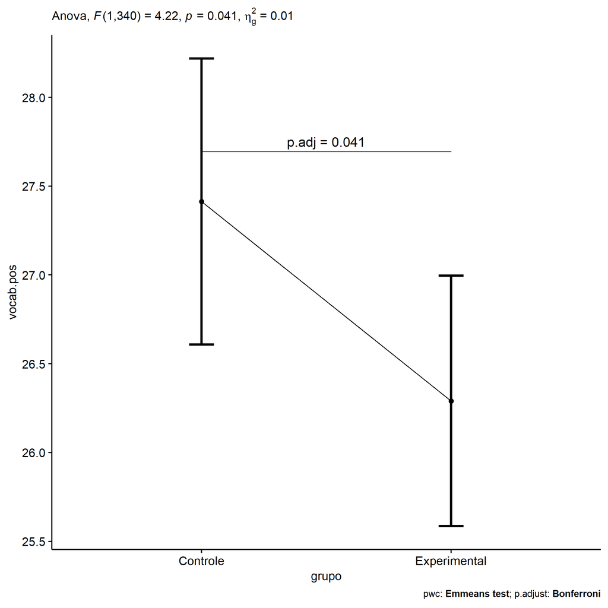

```r
if (!is.null(nrow(plots[["grupo"]]$data)))
  plots[["grupo"]] + ggplot2::scale_color_manual(values = color[["grupo"]])
```

```r
plots <- oneWayAncovaBoxPlots(
  wdat, "vocab.pos", "grupo", aov, pwc, covar = "vocab.pre",
  theme = "classic", color = color[["grupo"]],
  subtitle = which(aov$Effect == "grupo"))
```

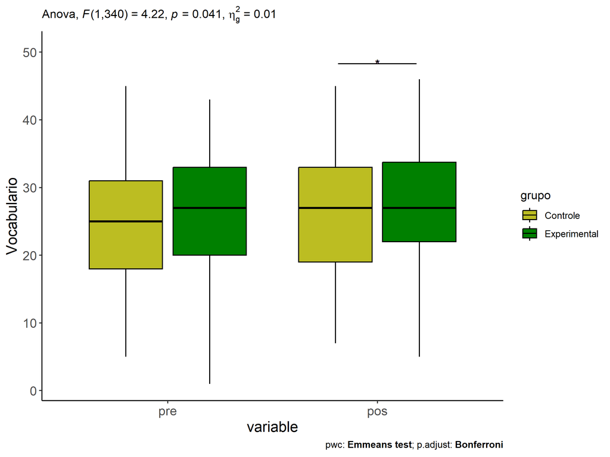

```r
if (length(unique(wdat[["grupo"]])) > 1)
  plots[["grupo"]] + ggplot2::ylab("Vocabulario") + ggplot2::scale_x_discrete(labels=c('pre', 'pos'))
```

```r
if (length(unique(wdat.long[["grupo"]])) > 1)
  plots <- oneWayAncovaBoxPlots(
    wdat.long, "vocab", "grupo", aov, pwc.long, pre.post = "time",
    theme = "classic", color = color$prepost)
```

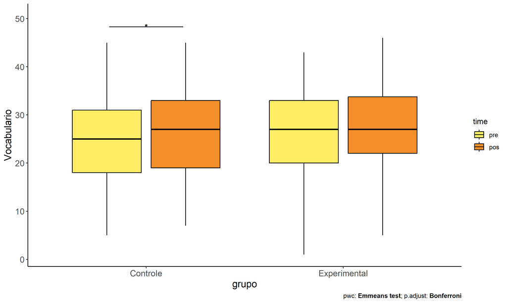

```r
if (length(unique(wdat.long[["grupo"]])) > 1)
  plots[["grupo"]] + ggplot2::ylab("Vocabulario")
```

### Checking linearity assumption

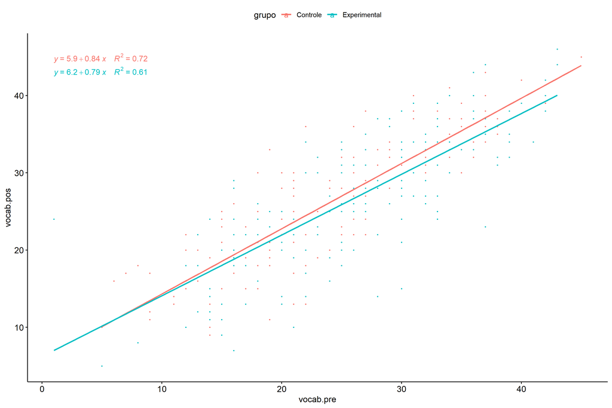

```r
ggscatter(wdat, x = "vocab.pre", y = "vocab.pos", size = 0.5,
          color = "grupo", add = "reg.line")+
  stat_regline_equation(
    aes(label =  paste(..eq.label.., ..rr.label.., sep = "~~~~"), color = grupo)
  )
```

### Checking normality and homogeneity

```r
res <- augment(lm(vocab.pos ~ vocab.pre + grupo, data = wdat))
```

```r
shapiro_test(res$.resid)
```

```
## # A tibble: 1 × 3
##   variable   statistic p.value
##   <chr>          <dbl>   <dbl>
## 1 res$.resid     0.993   0.143
```

```r
levene_test(res, .resid ~ grupo)
```

```
## # A tibble: 1 × 4
##     df1   df2 statistic     p
##   <int> <int>     <dbl> <dbl>
## 1     1   341      1.53 0.216
```

# ANCOVA and Pairwise for two factors **grupo:Sexo**

## Without remove non-normal data

```r
pdat = remove_group_data(dat[!is.na(dat[["grupo"]]) & !is.na(dat[["Sexo"]]),], "vocab.pos", c("grupo","Sexo"))

pdat.long <- rbind(pdat[,c("id","grupo","Sexo")], pdat[,c("id","grupo","Sexo")])
pdat.long[["time"]] <- c(rep("pre", nrow(pdat)), rep("pos", nrow(pdat)))
pdat.long[["time"]] <- factor(pdat.long[["time"]], c("pre","pos"))
pdat.long[["vocab"]] <- c(pdat[["vocab.pre"]], pdat[["vocab.pos"]])

aov = anova_test(pdat, vocab.pos ~ vocab.pre + grupo*Sexo)
laov[["grupo:Sexo"]] <- get_anova_table(aov)
```

```r
pwcs <- list()
pwcs[["Sexo"]] <- emmeans_test(
  group_by(pdat, grupo), vocab.pos ~ Sexo,
  covariate = vocab.pre, p.adjust.method = "bonferroni")
pwcs[["grupo"]] <- emmeans_test(
  group_by(pdat, Sexo), vocab.pos ~ grupo,
  covariate = vocab.pre, p.adjust.method = "bonferroni")

pwc <- plyr::rbind.fill(pwcs[["grupo"]], pwcs[["Sexo"]])
pwc <- pwc[,c("grupo","Sexo", colnames(pwc)[!colnames(pwc) %in% c("grupo","Sexo")])]
```

```r
pwc.long <- emmeans_test(dplyr::group_by_at(pdat.long, c("grupo","Sexo")),
                         vocab ~ time,
                         p.adjust.method = "bonferroni")
lpwc[["grupo:Sexo"]] <- plyr::rbind.fill(pwc, pwc.long)
```

```r
ds <- get.descriptives(pdat, "vocab.pos", c("grupo","Sexo"), covar = "vocab.pre")
ds <- merge(ds[ds$variable != "vocab.pre",],
            ds[ds$variable == "vocab.pre", !colnames(ds) %in% c("variable")],
            by = c("grupo","Sexo"), all.x = T, suffixes = c("", ".vocab.pre"))
ds <- merge(get_emmeans(pwcs[["grupo"]]), ds, by = c("grupo","Sexo"), suffixes = c(".emms", ""))
ds <- ds[,c("grupo","Sexo","n","mean.vocab.pre","se.vocab.pre","mean","se","emmean","se.emms")]

colnames(ds) <- c("grupo","Sexo", "N", paste0(c("M","SE")," (pre)"),
                  paste0(c("M","SE"), " (unadj)"), paste0(c("M", "SE"), " (adj)"))

lemms[["grupo:Sexo"]] <- ds
```

## Computing ANCOVA and PairWise After removing non-normal data (OK)

```r
wdat = pdat

res = residuals(lm(vocab.pos ~ vocab.pre + grupo*Sexo, data = wdat))
non.normal = getNonNormal(res, wdat$id, plimit = 0.05)

wdat = wdat[!wdat$id %in% non.normal,]

wdat.long <- rbind(wdat[,c("id","grupo","Sexo")], wdat[,c("id","grupo","Sexo")])
wdat.long[["time"]] <- c(rep("pre", nrow(wdat)), rep("pos", nrow(wdat)))
wdat.long[["time"]] <- factor(wdat.long[["time"]], c("pre","pos"))
wdat.long[["vocab"]] <- c(wdat[["vocab.pre"]], wdat[["vocab.pos"]])


ldat[["grupo:Sexo"]] = wdat

(non.normal)
```

```
## [1] "P983"  "P3042" "P1966" "P1961" "P1936"
```

```r
aov = anova_test(wdat, vocab.pos ~ vocab.pre + grupo*Sexo)
laov[["grupo:Sexo"]] <- merge(get_anova_table(aov), laov[["grupo:Sexo"]], by="Effect", suffixes = c("","'"))

(df = get_anova_table(aov))
```

```
## ANOVA Table (type II tests)
##
##       Effect DFn DFd       F        p p<.05   ges
## 1  vocab.pre   1 339 630.406 2.43e-79     * 0.650
## 2      grupo   1 339   2.786 9.60e-02       0.008
## 3       Sexo   1 339   4.075 4.40e-02     * 0.012
## 4 grupo:Sexo   1 339   3.995 4.60e-02     * 0.012
```

| Effect | DFn | DFd | F | p | p<.05 | ges |
| --- | --- | --- | --- | --- | --- | --- |
| vocab.pre | 1 | 339 | 630.406 | 0.000 | * | 0.650 |
| grupo | 1 | 339 | 2.786 | 0.096 |  | 0.008 |
| Sexo | 1 | 339 | 4.075 | 0.044 | * | 0.012 |
| grupo:Sexo | 1 | 339 | 3.995 | 0.046 | * | 0.012 |

```r
pwcs <- list()
pwcs[["Sexo"]] <- emmeans_test(
  group_by(wdat, grupo), vocab.pos ~ Sexo,
  covariate = vocab.pre, p.adjust.method = "bonferroni")
pwcs[["grupo"]] <- emmeans_test(
  group_by(wdat, Sexo), vocab.pos ~ grupo,
  covariate = vocab.pre, p.adjust.method = "bonferroni")

pwc <- plyr::rbind.fill(pwcs[["grupo"]], pwcs[["Sexo"]])
pwc <- pwc[,c("grupo","Sexo", colnames(pwc)[!colnames(pwc) %in% c("grupo","Sexo")])]
```

| grupo | Sexo | term | .y. | group1 | group2 | df | statistic | p | p.adj | p.adj.signif |
| --- | --- | --- | --- | --- | --- | --- | --- | --- | --- | --- |
|  | F | vocab.pre*grupo | vocab.pos | Controle | Experimental | 339 | -0.107 | 0.915 | 0.915 | ns |
|  | M | vocab.pre*grupo | vocab.pos | Controle | Experimental | 339 | 2.601 | 0.010 | 0.010 | ** |
| Controle |  | vocab.pre*Sexo | vocab.pos | F | M | 339 | -0.193 | 0.847 | 0.847 | ns |
| Experimental |  | vocab.pre*Sexo | vocab.pos | F | M | 339 | 2.835 | 0.005 | 0.005 | ** |

```r
pwc.long <- emmeans_test(dplyr::group_by_at(wdat.long, c("grupo","Sexo")),
                         vocab ~ time,
                         p.adjust.method = "bonferroni")
lpwc[["grupo:Sexo"]] <- merge(plyr::rbind.fill(pwc, pwc.long), lpwc[["grupo:Sexo"]], by=c("grupo","Sexo","term",".y.","group1","group2"), suffixes = c("","'"))
```

| grupo | Sexo | term | .y. | group1 | group2 | df | statistic | p | p.adj | p.adj.signif |
| --- | --- | --- | --- | --- | --- | --- | --- | --- | --- | --- |
| Controle | F | time | vocab | pre | pos | 680 | -1.271 | 0.204 | 0.204 | ns |
| Controle | M | time | vocab | pre | pos | 680 | -1.620 | 0.106 | 0.106 | ns |
| Experimental | F | time | vocab | pre | pos | 680 | -1.345 | 0.179 | 0.179 | ns |
| Experimental | M | time | vocab | pre | pos | 680 | 0.419 | 0.676 | 0.676 | ns |

```r
ds <- get.descriptives(wdat, "vocab.pos", c("grupo","Sexo"), covar = "vocab.pre")
ds <- merge(ds[ds$variable != "vocab.pre",],
            ds[ds$variable == "vocab.pre", !colnames(ds) %in% c("variable")],
            by = c("grupo","Sexo"), all.x = T, suffixes = c("", ".vocab.pre"))
ds <- merge(get_emmeans(pwcs[["grupo"]]), ds, by = c("grupo","Sexo"), suffixes = c(".emms", ""))
ds <- ds[,c("grupo","Sexo","n","mean.vocab.pre","se.vocab.pre","mean","se","emmean","se.emms")]

colnames(ds) <- c("grupo","Sexo", "N", paste0(c("M","SE")," (pre)"),
                  paste0(c("M","SE"), " (unadj)"), paste0(c("M", "SE"), " (adj)"))

lemms[["grupo:Sexo"]] <- merge(ds, lemms[["grupo:Sexo"]], by=c("grupo","Sexo"), suffixes = c("","'"))
```

| grupo | Sexo | N | M (pre) | SE (pre) | M (unadj) | SE (unadj) | M (adj) | SE (adj) |
| --- | --- | --- | --- | --- | --- | --- | --- | --- |
| Controle | F | 85 | 25.718 | 0.888 | 27.365 | 0.870 | 27.252 | 0.543 |
| Controle | M | 65 | 22.646 | 1.135 | 25.046 | 1.156 | 27.413 | 0.628 |
| Experimental | F | 98 | 26.255 | 0.839 | 27.878 | 0.773 | 27.331 | 0.506 |
| Experimental | M | 96 | 26.750 | 0.848 | 26.240 | 0.915 | 25.294 | 0.512 |

### Plots for ancova

```r
plots <- twoWayAncovaPlots(
  wdat, "vocab.pos", c("grupo","Sexo"), aov, pwcs, addParam = c("mean_se"),
  font.label.size=10, step.increase=0.05, p.label="p.adj",
  subtitle = which(aov$Effect == "grupo:Sexo"))
```

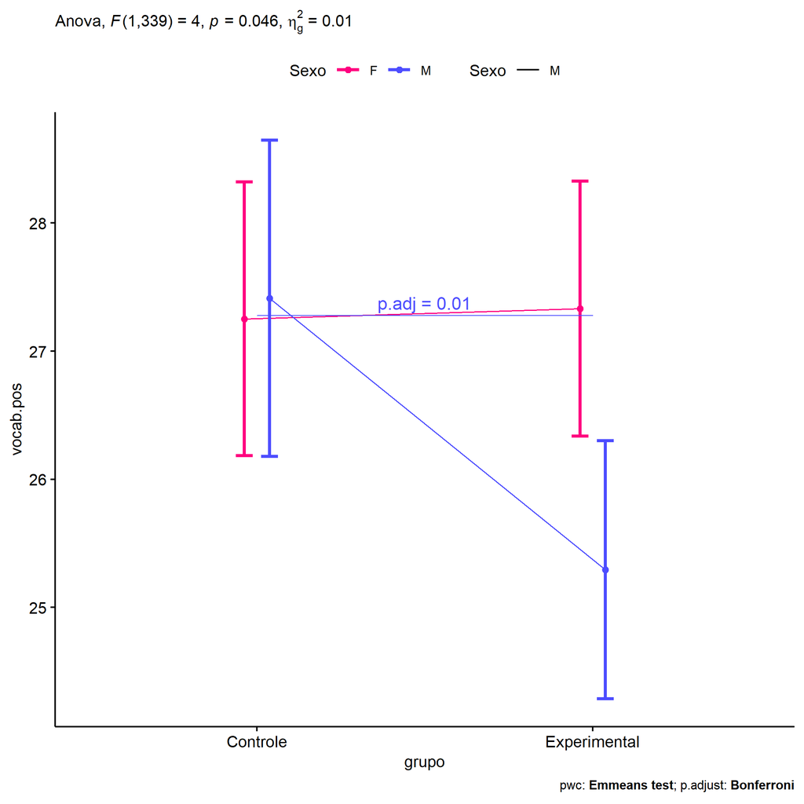

```r
if (!is.null(plots[["grupo"]]))
  plots[["grupo"]] + ggplot2::scale_color_manual(values = color[["Sexo"]])
```

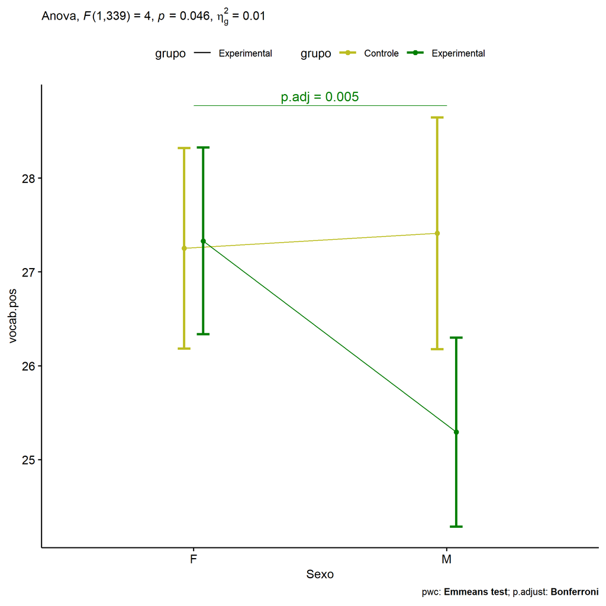

```r
if (!is.null(plots[["Sexo"]]))
  plots[["Sexo"]] + ggplot2::scale_color_manual(values = color[["grupo"]])
```

```r
plots <- twoWayAncovaBoxPlots(
  wdat, "vocab.pos", c("grupo","Sexo"), aov, pwcs, covar = "vocab.pre",
  theme = "classic", color = color[["grupo:Sexo"]],
  subtitle = which(aov$Effect == "grupo:Sexo"))
```

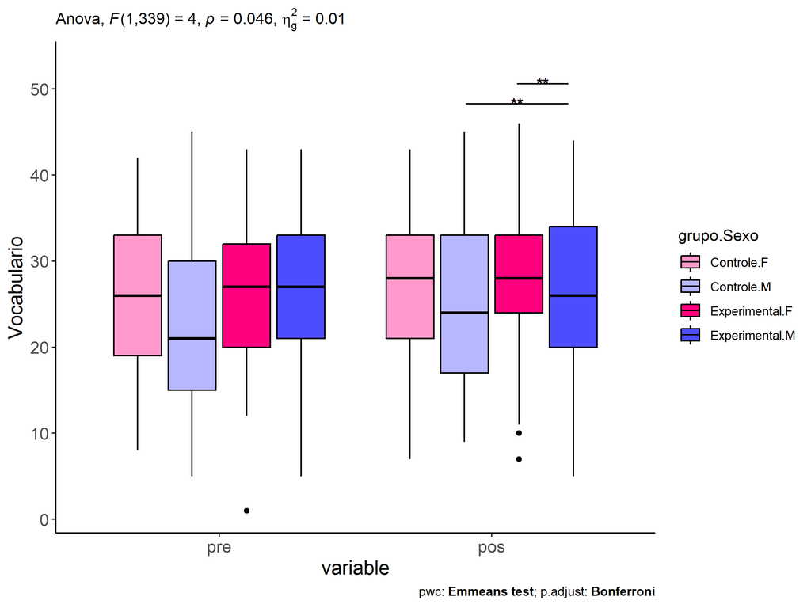

```r
plots[["grupo:Sexo"]] + ggplot2::ylab("Vocabulario") + ggplot2::scale_x_discrete(labels=c('pre', 'pos'))
```

```r
plots <- twoWayAncovaBoxPlots(
  wdat.long, "vocab", c("grupo","Sexo"), aov, pwc.long, pre.post = "time",
  theme = "classic", color = color$prepost)
```

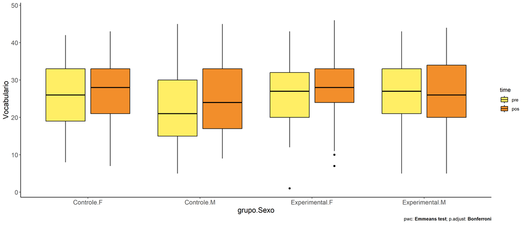

```r
plots[["grupo:Sexo"]] + ggplot2::ylab("Vocabulario")
```

### Checking linearity assumption

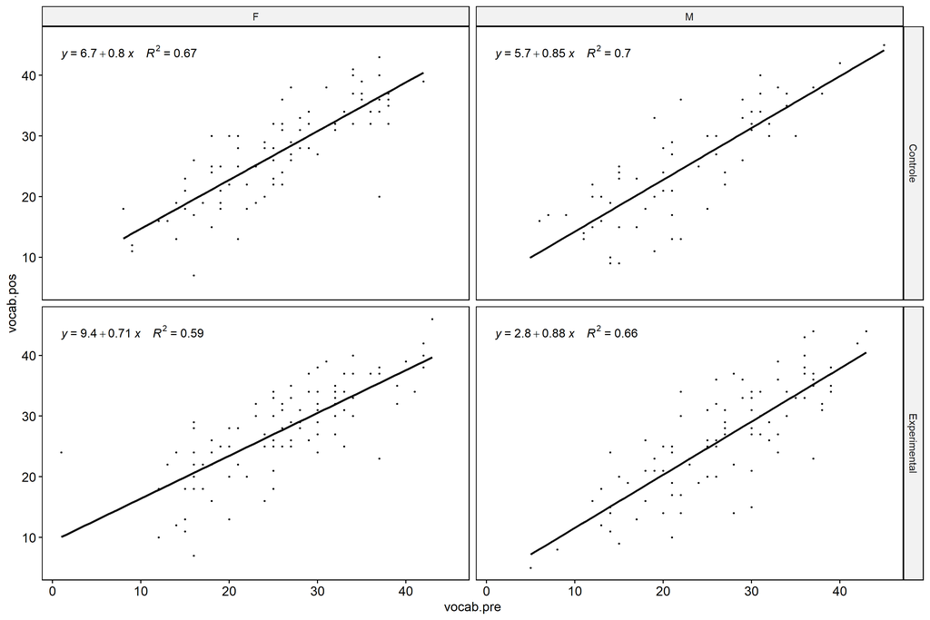

```r
ggscatter(wdat, x = "vocab.pre", y = "vocab.pos", size = 0.5,
          facet.by = c("grupo","Sexo"), add = "reg.line")+
  stat_regline_equation(
    aes(label =  paste(..eq.label.., ..rr.label.., sep = "~~~~"))
  )
```

### Checking normality and homogeneity

```r
res <- augment(lm(vocab.pos ~ vocab.pre + grupo*Sexo, data = wdat))
```

```r
shapiro_test(res$.resid)
```

```
## # A tibble: 1 × 3
##   variable   statistic p.value
##   <chr>          <dbl>   <dbl>
## 1 res$.resid     0.993  0.0826
```

```r
levene_test(res, .resid ~ grupo*Sexo)
```

```
## # A tibble: 1 × 4
##     df1   df2 statistic     p
##   <int> <int>     <dbl> <dbl>
## 1     3   340     0.654 0.581
```

# ANCOVA and Pairwise for two factors **grupo:Zona**

## Without remove non-normal data

```r
pdat = remove_group_data(dat[!is.na(dat[["grupo"]]) & !is.na(dat[["Zona"]]),], "vocab.pos", c("grupo","Zona"))

pdat.long <- rbind(pdat[,c("id","grupo","Zona")], pdat[,c("id","grupo","Zona")])
pdat.long[["time"]] <- c(rep("pre", nrow(pdat)), rep("pos", nrow(pdat)))
pdat.long[["time"]] <- factor(pdat.long[["time"]], c("pre","pos"))
pdat.long[["vocab"]] <- c(pdat[["vocab.pre"]], pdat[["vocab.pos"]])

aov = anova_test(pdat, vocab.pos ~ vocab.pre + grupo*Zona)
laov[["grupo:Zona"]] <- get_anova_table(aov)
```

```r
pwcs <- list()
pwcs[["Zona"]] <- emmeans_test(
  group_by(pdat, grupo), vocab.pos ~ Zona,
  covariate = vocab.pre, p.adjust.method = "bonferroni")
pwcs[["grupo"]] <- emmeans_test(
  group_by(pdat, Zona), vocab.pos ~ grupo,
  covariate = vocab.pre, p.adjust.method = "bonferroni")

pwc <- plyr::rbind.fill(pwcs[["grupo"]], pwcs[["Zona"]])
pwc <- pwc[,c("grupo","Zona", colnames(pwc)[!colnames(pwc) %in% c("grupo","Zona")])]
```

```r
pwc.long <- emmeans_test(dplyr::group_by_at(pdat.long, c("grupo","Zona")),
                         vocab ~ time,
                         p.adjust.method = "bonferroni")
lpwc[["grupo:Zona"]] <- plyr::rbind.fill(pwc, pwc.long)
```

```r
ds <- get.descriptives(pdat, "vocab.pos", c("grupo","Zona"), covar = "vocab.pre")
ds <- merge(ds[ds$variable != "vocab.pre",],
            ds[ds$variable == "vocab.pre", !colnames(ds) %in% c("variable")],
            by = c("grupo","Zona"), all.x = T, suffixes = c("", ".vocab.pre"))
ds <- merge(get_emmeans(pwcs[["grupo"]]), ds, by = c("grupo","Zona"), suffixes = c(".emms", ""))
ds <- ds[,c("grupo","Zona","n","mean.vocab.pre","se.vocab.pre","mean","se","emmean","se.emms")]

colnames(ds) <- c("grupo","Zona", "N", paste0(c("M","SE")," (pre)"),
                  paste0(c("M","SE"), " (unadj)"), paste0(c("M", "SE"), " (adj)"))

lemms[["grupo:Zona"]] <- ds
```

## Computing ANCOVA and PairWise After removing non-normal data (OK)

```r
wdat = pdat

res = residuals(lm(vocab.pos ~ vocab.pre + grupo*Zona, data = wdat))
non.normal = getNonNormal(res, wdat$id, plimit = 0.05)

wdat = wdat[!wdat$id %in% non.normal,]

wdat.long <- rbind(wdat[,c("id","grupo","Zona")], wdat[,c("id","grupo","Zona")])
wdat.long[["time"]] <- c(rep("pre", nrow(wdat)), rep("pos", nrow(wdat)))
wdat.long[["time"]] <- factor(wdat.long[["time"]], c("pre","pos"))
wdat.long[["vocab"]] <- c(wdat[["vocab.pre"]], wdat[["vocab.pos"]])


ldat[["grupo:Zona"]] = wdat

(non.normal)
```

```
## [1] "P983"  "P1966" "P3042" "P976"  "P1961"
```

```r
aov = anova_test(wdat, vocab.pos ~ vocab.pre + grupo*Zona)
laov[["grupo:Zona"]] <- merge(get_anova_table(aov), laov[["grupo:Zona"]], by="Effect", suffixes = c("","'"))

(df = get_anova_table(aov))
```

```
## ANOVA Table (type II tests)
##
##       Effect DFn DFd       F        p p<.05      ges
## 1  vocab.pre   1 285 550.594 1.57e-68     * 0.659000
## 2      grupo   1 285   4.491 3.50e-02     * 0.016000
## 3       Zona   1 285   0.056 8.13e-01       0.000196
## 4 grupo:Zona   1 285   3.392 6.70e-02       0.012000
```

| Effect | DFn | DFd | F | p | p<.05 | ges |
| --- | --- | --- | --- | --- | --- | --- |
| vocab.pre | 1 | 285 | 550.594 | 0.000 | * | 0.659 |
| grupo | 1 | 285 | 4.491 | 0.035 | * | 0.016 |
| Zona | 1 | 285 | 0.056 | 0.813 |  | 0.000 |
| grupo:Zona | 1 | 285 | 3.392 | 0.067 |  | 0.012 |

```r
pwcs <- list()
pwcs[["Zona"]] <- emmeans_test(
  group_by(wdat, grupo), vocab.pos ~ Zona,
  covariate = vocab.pre, p.adjust.method = "bonferroni")
pwcs[["grupo"]] <- emmeans_test(
  group_by(wdat, Zona), vocab.pos ~ grupo,
  covariate = vocab.pre, p.adjust.method = "bonferroni")

pwc <- plyr::rbind.fill(pwcs[["grupo"]], pwcs[["Zona"]])
pwc <- pwc[,c("grupo","Zona", colnames(pwc)[!colnames(pwc) %in% c("grupo","Zona")])]
```

| grupo | Zona | term | .y. | group1 | group2 | df | statistic | p | p.adj | p.adj.signif |
| --- | --- | --- | --- | --- | --- | --- | --- | --- | --- | --- |
|  | Rural | vocab.pre*grupo | vocab.pos | Controle | Experimental | 285 | 2.807 | 0.005 | 0.005 | ** |
|  | Urbana | vocab.pre*grupo | vocab.pos | Controle | Experimental | 285 | -0.025 | 0.980 | 0.980 | ns |
| Controle |  | vocab.pre*Zona | vocab.pos | Rural | Urbana | 285 | 1.557 | 0.121 | 0.121 | ns |
| Experimental |  | vocab.pre*Zona | vocab.pos | Rural | Urbana | 285 | -1.010 | 0.313 | 0.313 | ns |

```r
pwc.long <- emmeans_test(dplyr::group_by_at(wdat.long, c("grupo","Zona")),
                         vocab ~ time,
                         p.adjust.method = "bonferroni")
lpwc[["grupo:Zona"]] <- merge(plyr::rbind.fill(pwc, pwc.long), lpwc[["grupo:Zona"]], by=c("grupo","Zona","term",".y.","group1","group2"), suffixes = c("","'"))
```

| grupo | Zona | term | .y. | group1 | group2 | df | statistic | p | p.adj | p.adj.signif |
| --- | --- | --- | --- | --- | --- | --- | --- | --- | --- | --- |
| Controle | Rural | time | vocab | pre | pos | 572 | -1.957 | 0.051 | 0.051 | ns |
| Controle | Urbana | time | vocab | pre | pos | 572 | -0.608 | 0.543 | 0.543 | ns |
| Experimental | Rural | time | vocab | pre | pos | 572 | -0.158 | 0.875 | 0.875 | ns |
| Experimental | Urbana | time | vocab | pre | pos | 572 | -0.656 | 0.512 | 0.512 | ns |

```r
ds <- get.descriptives(wdat, "vocab.pos", c("grupo","Zona"), covar = "vocab.pre")
ds <- merge(ds[ds$variable != "vocab.pre",],
            ds[ds$variable == "vocab.pre", !colnames(ds) %in% c("variable")],
            by = c("grupo","Zona"), all.x = T, suffixes = c("", ".vocab.pre"))
ds <- merge(get_emmeans(pwcs[["grupo"]]), ds, by = c("grupo","Zona"), suffixes = c(".emms", ""))
ds <- ds[,c("grupo","Zona","n","mean.vocab.pre","se.vocab.pre","mean","se","emmean","se.emms")]

colnames(ds) <- c("grupo","Zona", "N", paste0(c("M","SE")," (pre)"),
                  paste0(c("M","SE"), " (unadj)"), paste0(c("M", "SE"), " (adj)"))

lemms[["grupo:Zona"]] <- merge(ds, lemms[["grupo:Zona"]], by=c("grupo","Zona"), suffixes = c("","'"))
```

| grupo | Zona | N | M (pre) | SE (pre) | M (unadj) | SE (unadj) | M (adj) | SE (adj) |
| --- | --- | --- | --- | --- | --- | --- | --- | --- |
| Controle | Rural | 75 | 24.707 | 0.968 | 27.413 | 0.982 | 28.529 | 0.577 |
| Controle | Urbana | 49 | 26.041 | 1.243 | 27.082 | 1.239 | 27.102 | 0.712 |
| Experimental | Rural | 91 | 26.495 | 0.887 | 26.692 | 0.918 | 26.340 | 0.523 |
| Experimental | Urbana | 75 | 26.920 | 0.950 | 27.827 | 0.938 | 27.125 | 0.576 |

### Plots for ancova

```r
plots <- twoWayAncovaPlots(
  wdat, "vocab.pos", c("grupo","Zona"), aov, pwcs, addParam = c("mean_se"),
  font.label.size=10, step.increase=0.05, p.label="p.adj",
  subtitle = which(aov$Effect == "grupo:Zona"))
```

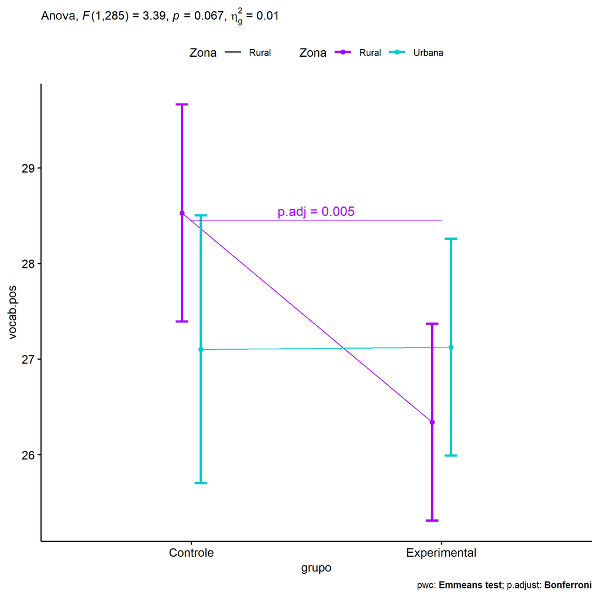

```r
if (!is.null(plots[["grupo"]]))
  plots[["grupo"]] + ggplot2::scale_color_manual(values = color[["Zona"]])
```

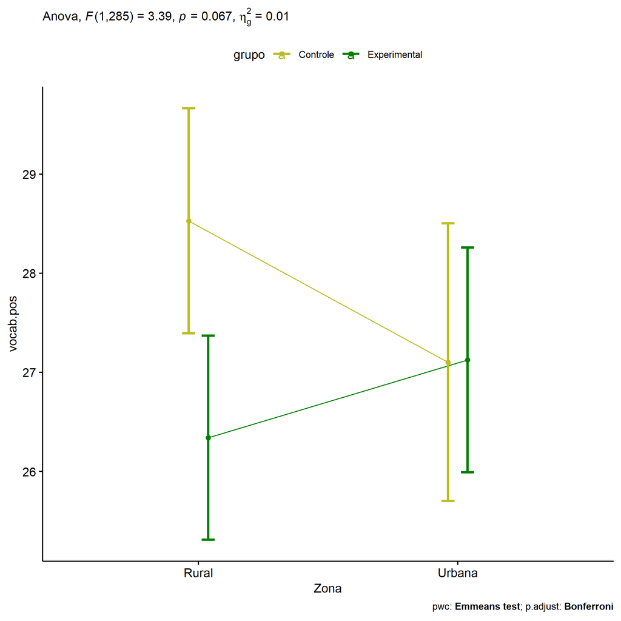

```r
if (!is.null(plots[["Zona"]]))
  plots[["Zona"]] + ggplot2::scale_color_manual(values = color[["grupo"]])
```

```r
plots <- twoWayAncovaBoxPlots(
  wdat, "vocab.pos", c("grupo","Zona"), aov, pwcs, covar = "vocab.pre",
  theme = "classic", color = color[["grupo:Zona"]],
  subtitle = which(aov$Effect == "grupo:Zona"))
```

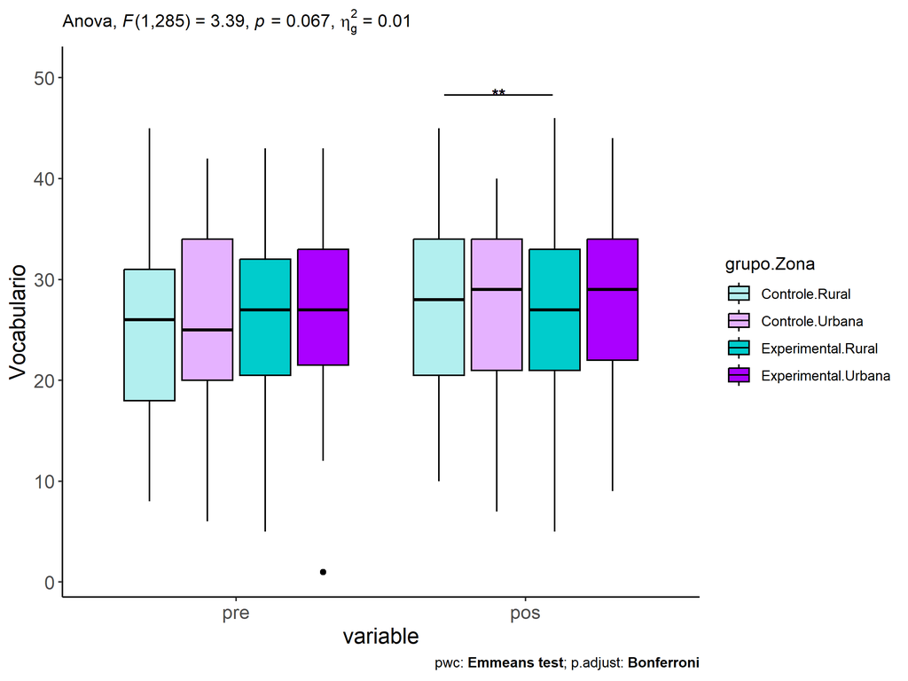

```r
plots[["grupo:Zona"]] + ggplot2::ylab("Vocabulario") + ggplot2::scale_x_discrete(labels=c('pre', 'pos'))
```

```r
plots <- twoWayAncovaBoxPlots(
  wdat.long, "vocab", c("grupo","Zona"), aov, pwc.long, pre.post = "time",
  theme = "classic", color = color$prepost)
```

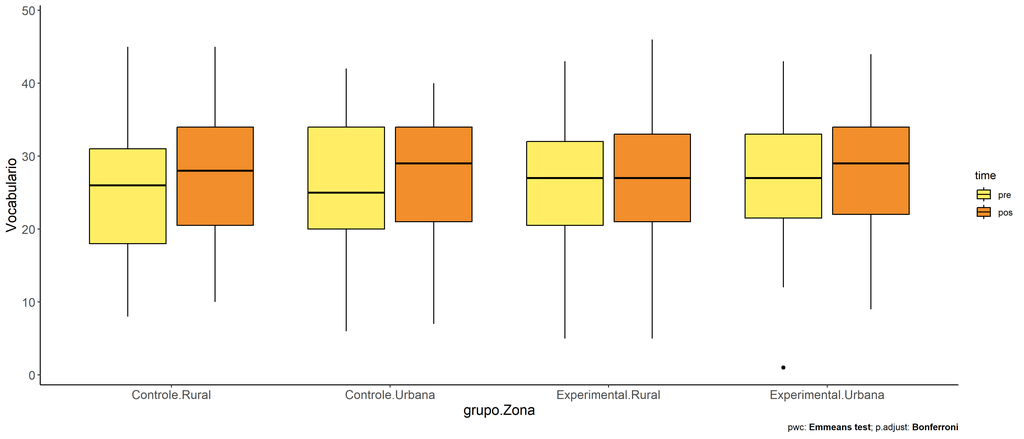

```r
plots[["grupo:Zona"]] + ggplot2::ylab("Vocabulario")
```

### Checking linearity assumption

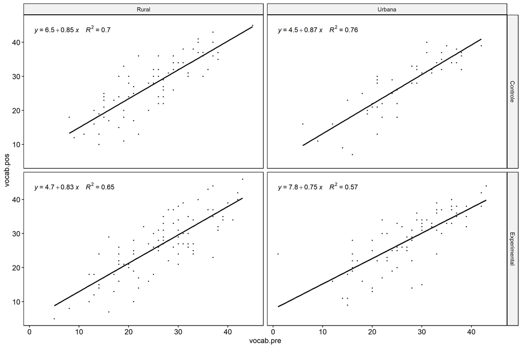

```r
ggscatter(wdat, x = "vocab.pre", y = "vocab.pos", size = 0.5,
          facet.by = c("grupo","Zona"), add = "reg.line")+
  stat_regline_equation(
    aes(label =  paste(..eq.label.., ..rr.label.., sep = "~~~~"))
  )
```

### Checking normality and homogeneity

```r
res <- augment(lm(vocab.pos ~ vocab.pre + grupo*Zona, data = wdat))
```

```r
shapiro_test(res$.resid)
```

```
## # A tibble: 1 × 3
##   variable   statistic p.value
##   <chr>          <dbl>   <dbl>
## 1 res$.resid     0.992   0.134
```

```r
levene_test(res, .resid ~ grupo*Zona)
```

```
## # A tibble: 1 × 4
##     df1   df2 statistic     p
##   <int> <int>     <dbl> <dbl>
## 1     3   286      1.18 0.316
```

# ANCOVA and Pairwise for two factors **grupo:Cor.Raca**

## Without remove non-normal data

```r
pdat = remove_group_data(dat[!is.na(dat[["grupo"]]) & !is.na(dat[["Cor.Raca"]]),], "vocab.pos", c("grupo","Cor.Raca"))

pdat.long <- rbind(pdat[,c("id","grupo","Cor.Raca")], pdat[,c("id","grupo","Cor.Raca")])
pdat.long[["time"]] <- c(rep("pre", nrow(pdat)), rep("pos", nrow(pdat)))
pdat.long[["time"]] <- factor(pdat.long[["time"]], c("pre","pos"))
pdat.long[["vocab"]] <- c(pdat[["vocab.pre"]], pdat[["vocab.pos"]])

aov = anova_test(pdat, vocab.pos ~ vocab.pre + grupo*Cor.Raca)
laov[["grupo:Cor.Raca"]] <- get_anova_table(aov)
```

```r
pwcs <- list()
pwcs[["Cor.Raca"]] <- emmeans_test(
  group_by(pdat, grupo), vocab.pos ~ Cor.Raca,
  covariate = vocab.pre, p.adjust.method = "bonferroni")
pwcs[["grupo"]] <- emmeans_test(
  group_by(pdat, Cor.Raca), vocab.pos ~ grupo,
  covariate = vocab.pre, p.adjust.method = "bonferroni")

pwc <- plyr::rbind.fill(pwcs[["grupo"]], pwcs[["Cor.Raca"]])
pwc <- pwc[,c("grupo","Cor.Raca", colnames(pwc)[!colnames(pwc) %in% c("grupo","Cor.Raca")])]
```

```r
pwc.long <- emmeans_test(dplyr::group_by_at(pdat.long, c("grupo","Cor.Raca")),
                         vocab ~ time,
                         p.adjust.method = "bonferroni")
lpwc[["grupo:Cor.Raca"]] <- plyr::rbind.fill(pwc, pwc.long)
```

```r
ds <- get.descriptives(pdat, "vocab.pos", c("grupo","Cor.Raca"), covar = "vocab.pre")
ds <- merge(ds[ds$variable != "vocab.pre",],
            ds[ds$variable == "vocab.pre", !colnames(ds) %in% c("variable")],
            by = c("grupo","Cor.Raca"), all.x = T, suffixes = c("", ".vocab.pre"))
ds <- merge(get_emmeans(pwcs[["grupo"]]), ds, by = c("grupo","Cor.Raca"), suffixes = c(".emms", ""))
ds <- ds[,c("grupo","Cor.Raca","n","mean.vocab.pre","se.vocab.pre","mean","se","emmean","se.emms")]

colnames(ds) <- c("grupo","Cor.Raca", "N", paste0(c("M","SE")," (pre)"),
                  paste0(c("M","SE"), " (unadj)"), paste0(c("M", "SE"), " (adj)"))

lemms[["grupo:Cor.Raca"]] <- ds
```

## Computing ANCOVA and PairWise After removing non-normal data (OK)

```r
wdat = pdat

res = residuals(lm(vocab.pos ~ vocab.pre + grupo*Cor.Raca, data = wdat))
non.normal = getNonNormal(res, wdat$id, plimit = 0.05)

wdat = wdat[!wdat$id %in% non.normal,]

wdat.long <- rbind(wdat[,c("id","grupo","Cor.Raca")], wdat[,c("id","grupo","Cor.Raca")])
wdat.long[["time"]] <- c(rep("pre", nrow(wdat)), rep("pos", nrow(wdat)))
wdat.long[["time"]] <- factor(wdat.long[["time"]], c("pre","pos"))
wdat.long[["vocab"]] <- c(wdat[["vocab.pre"]], wdat[["vocab.pos"]])


ldat[["grupo:Cor.Raca"]] = wdat

(non.normal)
```

[output not shown]

```r
aov = anova_test(wdat, vocab.pos ~ vocab.pre + grupo*Cor.Raca)
laov[["grupo:Cor.Raca"]] <- merge(get_anova_table(aov), laov[["grupo:Cor.Raca"]], by="Effect", suffixes = c("","'"))

(df = get_anova_table(aov))
```

```
## ANOVA Table (type II tests)
##
##           Effect DFn DFd       F        p p<.05   ges
## 1      vocab.pre   1 133 198.508 3.73e-28     * 0.599
## 2          grupo   1 133   5.625 1.90e-02     * 0.041
## 3       Cor.Raca   2 133   1.585 2.09e-01       0.023
## 4 grupo:Cor.Raca   1 133   1.611 2.07e-01       0.012
```

| Effect | DFn | DFd | F | p | p<.05 | ges |
| --- | --- | --- | --- | --- | --- | --- |
| vocab.pre | 1 | 133 | 198.508 | 0.000 | * | 0.599 |
| grupo | 1 | 133 | 5.625 | 0.019 | * | 0.041 |
| Cor.Raca | 2 | 133 | 1.585 | 0.209 |  | 0.023 |
| grupo:Cor.Raca | 1 | 133 | 1.611 | 0.207 |  | 0.012 |

```r
pwcs <- list()
pwcs[["Cor.Raca"]] <- emmeans_test(
  group_by(wdat, grupo), vocab.pos ~ Cor.Raca,
  covariate = vocab.pre, p.adjust.method = "bonferroni")
pwcs[["grupo"]] <- emmeans_test(
  group_by(wdat, Cor.Raca), vocab.pos ~ grupo,
  covariate = vocab.pre, p.adjust.method = "bonferroni")

pwc <- plyr::rbind.fill(pwcs[["grupo"]], pwcs[["Cor.Raca"]])
pwc <- pwc[,c("grupo","Cor.Raca", colnames(pwc)[!colnames(pwc) %in% c("grupo","Cor.Raca")])]
```

| grupo | Cor.Raca | term | .y. | group1 | group2 | df | statistic | p | p.adj | p.adj.signif |
| --- | --- | --- | --- | --- | --- | --- | --- | --- | --- | --- |
|  | Branca | vocab.pre*grupo | vocab.pos | Controle | Experimental | 133 | 2.278 | 0.024 | 0.024 | * |
|  | Indígena | vocab.pre*grupo | vocab.pos | Controle | Experimental |  |  |  |  |  |
|  | Parda | vocab.pre*grupo | vocab.pos | Controle | Experimental | 133 | 1.433 | 0.154 | 0.154 | ns |
| Controle |  | vocab.pre*Cor.Raca | vocab.pos | Branca | Indígena | 133 | -1.120 | 0.265 | 0.794 | ns |
| Controle |  | vocab.pre*Cor.Raca | vocab.pos | Branca | Parda | 133 | -0.282 | 0.779 | 1.000 | ns |
| Controle |  | vocab.pre*Cor.Raca | vocab.pos | Indígena | Parda | 133 | 1.011 | 0.314 | 0.942 | ns |
| Experimental |  | vocab.pre*Cor.Raca | vocab.pos | Branca | Indígena |  |  |  |  |  |
| Experimental |  | vocab.pre*Cor.Raca | vocab.pos | Branca | Parda | 133 | -1.867 | 0.064 | 0.064 | ns |
| Experimental |  | vocab.pre*Cor.Raca | vocab.pos | Indígena | Parda |  |  |  |  |  |

```r
pwc.long <- emmeans_test(dplyr::group_by_at(wdat.long, c("grupo","Cor.Raca")),
                         vocab ~ time,
                         p.adjust.method = "bonferroni")
lpwc[["grupo:Cor.Raca"]] <- merge(plyr::rbind.fill(pwc, pwc.long), lpwc[["grupo:Cor.Raca"]], by=c("grupo","Cor.Raca","term",".y.","group1","group2"), suffixes = c("","'"))
```

| grupo | Cor.Raca | term | .y. | group1 | group2 | df | statistic | p | p.adj | p.adj.signif |
| --- | --- | --- | --- | --- | --- | --- | --- | --- | --- | --- |
| Controle | Branca | time | vocab | pre | pos | 268 | -0.691 | 0.490 | 0.490 | ns |
| Controle | Indígena | time | vocab | pre | pos | 268 | -1.116 | 0.265 | 0.265 | ns |
| Controle | Parda | time | vocab | pre | pos | 268 | -1.673 | 0.096 | 0.096 | ns |
| Experimental | Branca | time | vocab | pre | pos | 268 | 0.788 | 0.431 | 0.431 | ns |
| Experimental | Indígena | time | vocab | pre | pos |  |  |  |  |  |
| Experimental | Parda | time | vocab | pre | pos | 268 | -0.621 | 0.535 | 0.535 | ns |

```r
ds <- get.descriptives(wdat, "vocab.pos", c("grupo","Cor.Raca"), covar = "vocab.pre")
ds <- merge(ds[ds$variable != "vocab.pre",],
            ds[ds$variable == "vocab.pre", !colnames(ds) %in% c("variable")],
            by = c("grupo","Cor.Raca"), all.x = T, suffixes = c("", ".vocab.pre"))
ds <- merge(get_emmeans(pwcs[["grupo"]]), ds, by = c("grupo","Cor.Raca"), suffixes = c(".emms", ""))
ds <- ds[,c("grupo","Cor.Raca","n","mean.vocab.pre","se.vocab.pre","mean","se","emmean","se.emms")]

colnames(ds) <- c("grupo","Cor.Raca", "N", paste0(c("M","SE")," (pre)"),
                  paste0(c("M","SE"), " (unadj)"), paste0(c("M", "SE"), " (adj)"))

lemms[["grupo:Cor.Raca"]] <- merge(ds, lemms[["grupo:Cor.Raca"]], by=c("grupo","Cor.Raca"), suffixes = c("","'"))
```

| grupo | Cor.Raca | N | M (pre) | SE (pre) | M (unadj) | SE (unadj) | M (adj) | SE (adj) |
| --- | --- | --- | --- | --- | --- | --- | --- | --- |
| Controle | Branca | 22 | 26.273 | 1.742 | 28.000 | 1.686 | 26.482 | 1.128 |
| Controle | Indígena | 8 | 24.250 | 2.258 | 28.875 | 2.728 | 28.921 | 1.861 |
| Controle | Parda | 44 | 22.591 | 1.278 | 25.545 | 1.447 | 26.874 | 0.799 |
| Experimental | Branca | 12 | 26.667 | 2.013 | 24.000 | 2.067 | 22.178 | 1.525 |
| Experimental | Parda | 53 | 24.396 | 1.189 | 25.396 | 1.032 | 25.329 | 0.723 |

### Plots for ancova

```r
plots <- twoWayAncovaPlots(
  wdat, "vocab.pos", c("grupo","Cor.Raca"), aov, pwcs, addParam = c("mean_se"),
  font.label.size=10, step.increase=0.05, p.label="p.adj",
  subtitle = which(aov$Effect == "grupo:Cor.Raca"))
```

[figure not shown]

```r
if (!is.null(plots[["grupo"]]))
  plots[["grupo"]] + ggplot2::scale_color_manual(values = color[["Cor.Raca"]])
```

```
## Warning: Removed 2 rows containing non-finite values (`stat_bracket()`).

## Warning: Removed 1 rows containing missing values (`geom_point()`).
```

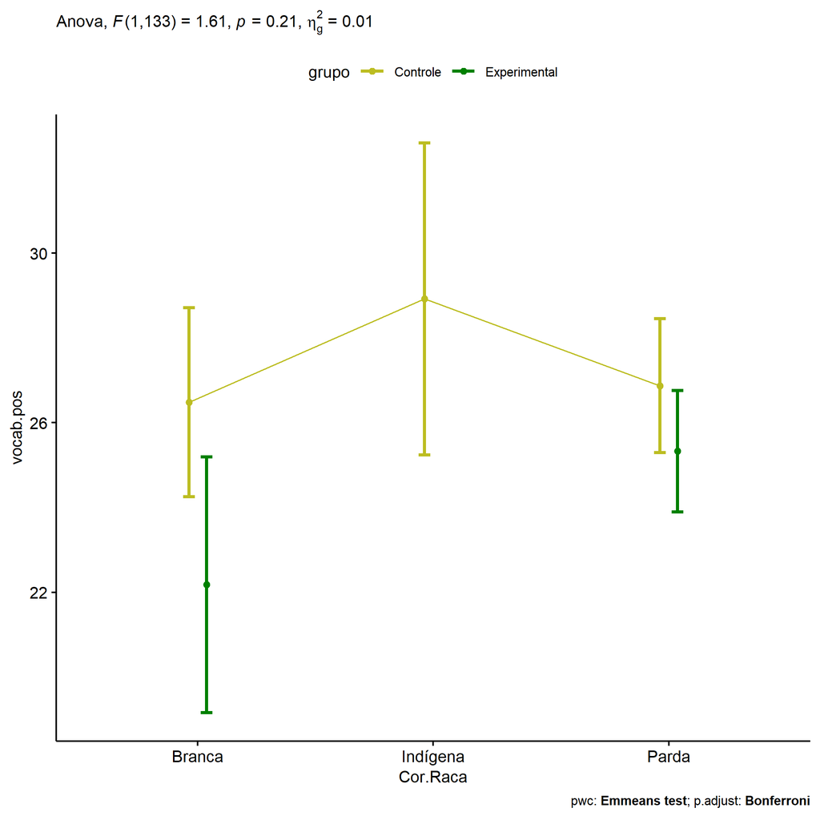

```r
if (!is.null(plots[["Cor.Raca"]]))
  plots[["Cor.Raca"]] + ggplot2::scale_color_manual(values = color[["grupo"]])
```

```r
plots <- twoWayAncovaBoxPlots(
  wdat, "vocab.pos", c("grupo","Cor.Raca"), aov, pwcs, covar = "vocab.pre",
  theme = "classic", color = color[["grupo:Cor.Raca"]],
  subtitle = which(aov$Effect == "grupo:Cor.Raca"))
```

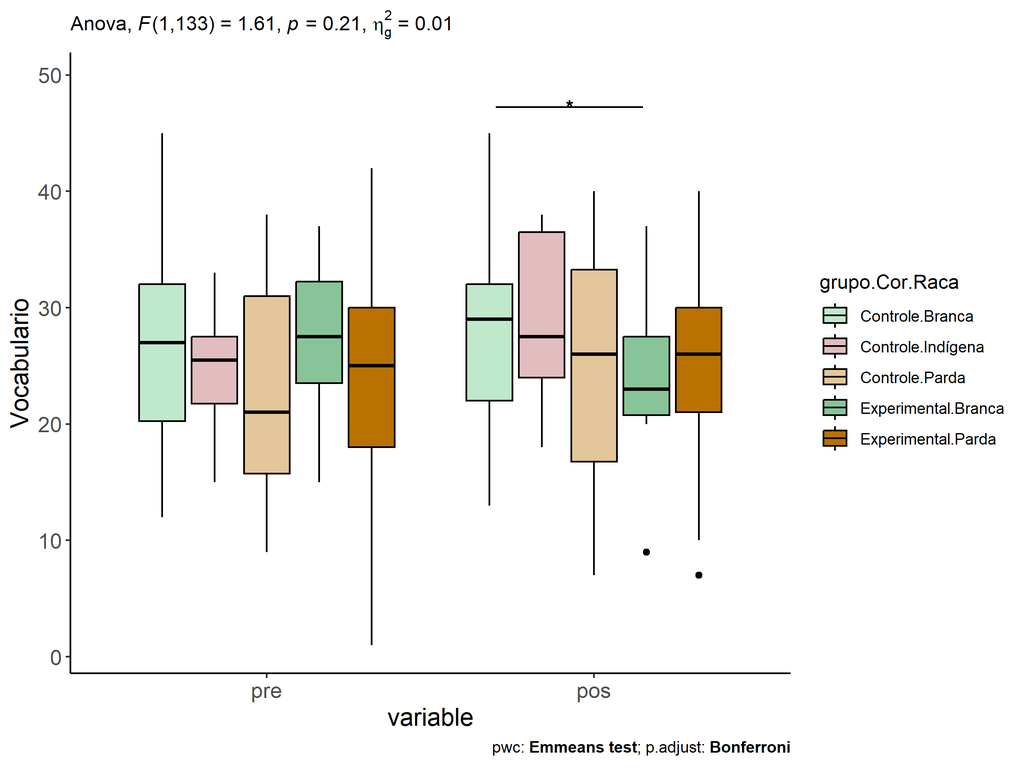

```r
plots[["grupo:Cor.Raca"]] + ggplot2::ylab("Vocabulario") + ggplot2::scale_x_discrete(labels=c('pre', 'pos'))
```

```r
plots <- twoWayAncovaBoxPlots(
  wdat.long, "vocab", c("grupo","Cor.Raca"), aov, pwc.long, pre.post = "time",
  theme = "classic", color = color$prepost)
```

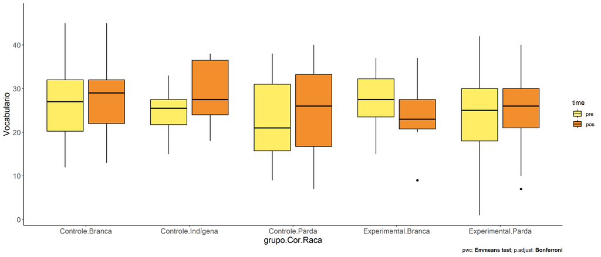

```r
plots[["grupo:Cor.Raca"]] + ggplot2::ylab("Vocabulario")
```

### Checking linearity assumption

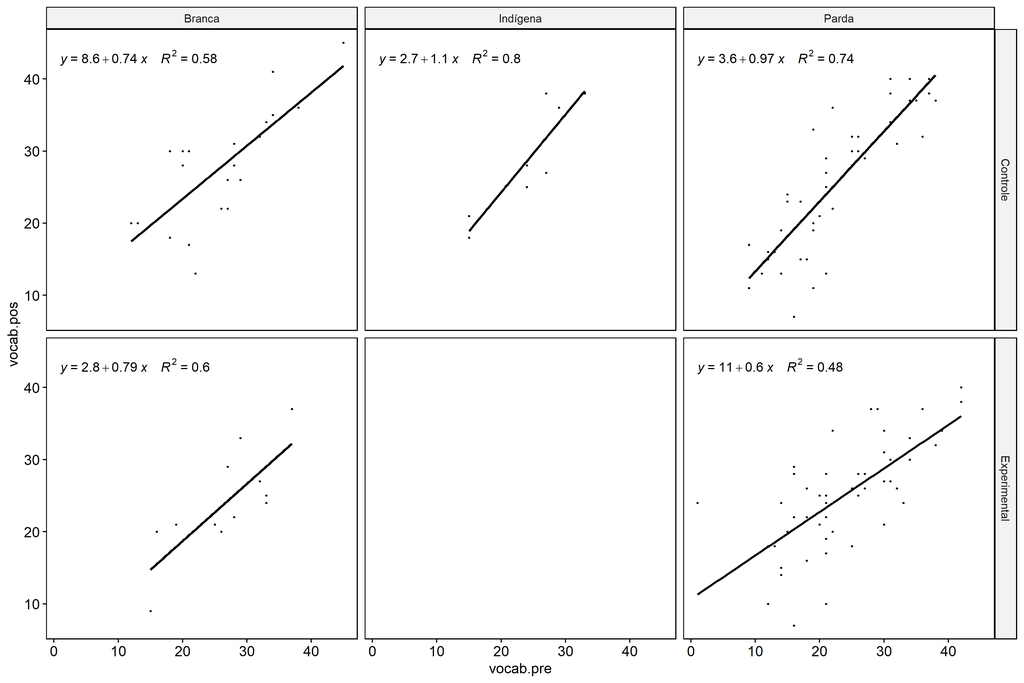

```r
ggscatter(wdat, x = "vocab.pre", y = "vocab.pos", size = 0.5,
          facet.by = c("grupo","Cor.Raca"), add = "reg.line")+
  stat_regline_equation(
    aes(label =  paste(..eq.label.., ..rr.label.., sep = "~~~~"))
  )
```

### Checking normality and homogeneity

```r
res <- augment(lm(vocab.pos ~ vocab.pre + grupo*Cor.Raca, data = wdat))
```

```r
shapiro_test(res$.resid)
```

```
## # A tibble: 1 × 3
##   variable   statistic p.value
##   <chr>          <dbl>   <dbl>
## 1 res$.resid     0.990   0.392
```

```r
levene_test(res, .resid ~ grupo*Cor.Raca)
```

```
## # A tibble: 1 × 4
##     df1   df2 statistic     p
##   <int> <int>     <dbl> <dbl>
## 1     4   134     0.218 0.928
```

# ANCOVA and Pairwise for two factors **grupo:vocab.quintile**

## Without remove non-normal data

```r
pdat = remove_group_data(dat[!is.na(dat[["grupo"]]) & !is.na(dat[["vocab.quintile"]]),], "vocab.pos", c("grupo","vocab.quintile"))

pdat.long <- rbind(pdat[,c("id","grupo","vocab.quintile")], pdat[,c("id","grupo","vocab.quintile")])
pdat.long[["time"]] <- c(rep("pre", nrow(pdat)), rep("pos", nrow(pdat)))
pdat.long[["time"]] <- factor(pdat.long[["time"]], c("pre","pos"))
pdat.long[["vocab"]] <- c(pdat[["vocab.pre"]], pdat[["vocab.pos"]])

aov = anova_test(pdat, vocab.pos ~ vocab.pre + grupo*vocab.quintile)
laov[["grupo:vocab.quintile"]] <- get_anova_table(aov)
```

```r
pwcs <- list()
pwcs[["vocab.quintile"]] <- emmeans_test(
  group_by(pdat, grupo), vocab.pos ~ vocab.quintile,
  covariate = vocab.pre, p.adjust.method = "bonferroni")
pwcs[["grupo"]] <- emmeans_test(
  group_by(pdat, vocab.quintile), vocab.pos ~ grupo,
  covariate = vocab.pre, p.adjust.method = "bonferroni")

pwc <- plyr::rbind.fill(pwcs[["grupo"]], pwcs[["vocab.quintile"]])
pwc <- pwc[,c("grupo","vocab.quintile", colnames(pwc)[!colnames(pwc) %in% c("grupo","vocab.quintile")])]
```

```r
pwc.long <- emmeans_test(dplyr::group_by_at(pdat.long, c("grupo","vocab.quintile")),
                         vocab ~ time,
                         p.adjust.method = "bonferroni")
lpwc[["grupo:vocab.quintile"]] <- plyr::rbind.fill(pwc, pwc.long)
```

```r
ds <- get.descriptives(pdat, "vocab.pos", c("grupo","vocab.quintile"), covar = "vocab.pre")
ds <- merge(ds[ds$variable != "vocab.pre",],
            ds[ds$variable == "vocab.pre", !colnames(ds) %in% c("variable")],
            by = c("grupo","vocab.quintile"), all.x = T, suffixes = c("", ".vocab.pre"))
ds <- merge(get_emmeans(pwcs[["grupo"]]), ds, by = c("grupo","vocab.quintile"), suffixes = c(".emms", ""))
ds <- ds[,c("grupo","vocab.quintile","n","mean.vocab.pre","se.vocab.pre","mean","se","emmean","se.emms")]

colnames(ds) <- c("grupo","vocab.quintile", "N", paste0(c("M","SE")," (pre)"),
                  paste0(c("M","SE"), " (unadj)"), paste0(c("M", "SE"), " (adj)"))

lemms[["grupo:vocab.quintile"]] <- ds
```

## Computing ANCOVA and PairWise After removing non-normal data (OK)

```r
wdat = pdat

res = residuals(lm(vocab.pos ~ vocab.pre + grupo*vocab.quintile, data = wdat))
non.normal = getNonNormal(res, wdat$id, plimit = 0.05)

wdat = wdat[!wdat$id %in% non.normal,]

wdat.long <- rbind(wdat[,c("id","grupo","vocab.quintile")], wdat[,c("id","grupo","vocab.quintile")])
wdat.long[["time"]] <- c(rep("pre", nrow(wdat)), rep("pos", nrow(wdat)))
wdat.long[["time"]] <- factor(wdat.long[["time"]], c("pre","pos"))
wdat.long[["vocab"]] <- c(wdat[["vocab.pre"]], wdat[["vocab.pos"]])


ldat[["grupo:vocab.quintile"]] = wdat

(non.normal)
```

```
## [1] "P983"  "P1966" "P1936" "P3042" "P2957"
```

```r
aov = anova_test(wdat, vocab.pos ~ vocab.pre + grupo*vocab.quintile)
laov[["grupo:vocab.quintile"]] <- merge(get_anova_table(aov), laov[["grupo:vocab.quintile"]], by="Effect", suffixes = c("","'"))

(df = get_anova_table(aov))
```

```
## ANOVA Table (type II tests)
##
##                 Effect DFn DFd      F        p p<.05   ges
## 1            vocab.pre   1 333 29.608 1.03e-07     * 0.082
## 2                grupo   1 333  3.536 6.10e-02       0.011
## 3       vocab.quintile   4 333  0.828 5.08e-01       0.010
## 4 grupo:vocab.quintile   4 333  1.138 3.39e-01       0.013
```

| Effect | DFn | DFd | F | p | p<.05 | ges |
| --- | --- | --- | --- | --- | --- | --- |
| vocab.pre | 1 | 333 | 29.608 | 0.000 | * | 0.082 |
| grupo | 1 | 333 | 3.536 | 0.061 |  | 0.011 |
| vocab.quintile | 4 | 333 | 0.828 | 0.508 |  | 0.010 |
| grupo:vocab.quintile | 4 | 333 | 1.138 | 0.339 |  | 0.013 |

```r
pwcs <- list()
pwcs[["vocab.quintile"]] <- emmeans_test(
  group_by(wdat, grupo), vocab.pos ~ vocab.quintile,
  covariate = vocab.pre, p.adjust.method = "bonferroni")
pwcs[["grupo"]] <- emmeans_test(
  group_by(wdat, vocab.quintile), vocab.pos ~ grupo,
  covariate = vocab.pre, p.adjust.method = "bonferroni")

pwc <- plyr::rbind.fill(pwcs[["grupo"]], pwcs[["vocab.quintile"]])
pwc <- pwc[,c("grupo","vocab.quintile", colnames(pwc)[!colnames(pwc) %in% c("grupo","vocab.quintile")])]
```

| grupo | vocab.quintile | term | .y. | group1 | group2 | df | statistic | p | p.adj | p.adj.signif |
| --- | --- | --- | --- | --- | --- | --- | --- | --- | --- | --- |
|  | 1st quintile | vocab.pre*grupo | vocab.pos | Controle | Experimental | 333 | 0.330 | 0.741 | 0.741 | ns |
|  | 2nd quintile | vocab.pre*grupo | vocab.pos | Controle | Experimental | 333 | 1.191 | 0.235 | 0.235 | ns |
|  | 3rd quintile | vocab.pre*grupo | vocab.pos | Controle | Experimental | 333 | 0.070 | 0.945 | 0.945 | ns |
|  | 4th quintile | vocab.pre*grupo | vocab.pos | Controle | Experimental | 333 | 2.552 | 0.011 | 0.011 | * |
|  | 5th quintile | vocab.pre*grupo | vocab.pos | Controle | Experimental | 333 | 0.162 | 0.871 | 0.871 | ns |
| Controle |  | vocab.pre*vocab.quintile | vocab.pos | 1st quintile | 2nd quintile | 333 | -0.238 | 0.812 | 1.000 | ns |
| Controle |  | vocab.pre*vocab.quintile | vocab.pos | 1st quintile | 3rd quintile | 333 | -0.708 | 0.479 | 1.000 | ns |
| Controle |  | vocab.pre*vocab.quintile | vocab.pos | 1st quintile | 4th quintile | 333 | -1.311 | 0.191 | 1.000 | ns |
| Controle |  | vocab.pre*vocab.quintile | vocab.pos | 1st quintile | 5th quintile | 333 | -0.528 | 0.598 | 1.000 | ns |
| Controle |  | vocab.pre*vocab.quintile | vocab.pos | 2nd quintile | 3rd quintile | 333 | -0.798 | 0.426 | 1.000 | ns |
| Controle |  | vocab.pre*vocab.quintile | vocab.pos | 2nd quintile | 4th quintile | 333 | -1.628 | 0.105 | 1.000 | ns |
| Controle |  | vocab.pre*vocab.quintile | vocab.pos | 2nd quintile | 5th quintile | 333 | -0.558 | 0.577 | 1.000 | ns |
| Controle |  | vocab.pre*vocab.quintile | vocab.pos | 3rd quintile | 4th quintile | 333 | -1.486 | 0.138 | 1.000 | ns |
| Controle |  | vocab.pre*vocab.quintile | vocab.pos | 3rd quintile | 5th quintile | 333 | -0.169 | 0.866 | 1.000 | ns |
| Controle |  | vocab.pre*vocab.quintile | vocab.pos | 4th quintile | 5th quintile | 333 | 1.180 | 0.239 | 1.000 | ns |
| Experimental |  | vocab.pre*vocab.quintile | vocab.pos | 1st quintile | 2nd quintile | 333 | 0.434 | 0.665 | 1.000 | ns |
| Experimental |  | vocab.pre*vocab.quintile | vocab.pos | 1st quintile | 3rd quintile | 333 | -0.942 | 0.347 | 1.000 | ns |
| Experimental |  | vocab.pre*vocab.quintile | vocab.pos | 1st quintile | 4th quintile | 333 | -0.351 | 0.725 | 1.000 | ns |
| Experimental |  | vocab.pre*vocab.quintile | vocab.pos | 1st quintile | 5th quintile | 333 | -0.601 | 0.548 | 1.000 | ns |
| Experimental |  | vocab.pre*vocab.quintile | vocab.pos | 2nd quintile | 3rd quintile | 333 | -1.839 | 0.067 | 0.667 | ns |
| Experimental |  | vocab.pre*vocab.quintile | vocab.pos | 2nd quintile | 4th quintile | 333 | -0.821 | 0.412 | 1.000 | ns |
| Experimental |  | vocab.pre*vocab.quintile | vocab.pos | 2nd quintile | 5th quintile | 333 | -1.015 | 0.311 | 1.000 | ns |
| Experimental |  | vocab.pre*vocab.quintile | vocab.pos | 3rd quintile | 4th quintile | 333 | 0.754 | 0.451 | 1.000 | ns |
| Experimental |  | vocab.pre*vocab.quintile | vocab.pos | 3rd quintile | 5th quintile | 333 | -0.097 | 0.923 | 1.000 | ns |
| Experimental |  | vocab.pre*vocab.quintile | vocab.pos | 4th quintile | 5th quintile | 333 | -0.801 | 0.424 | 1.000 | ns |

```r
pwc.long <- emmeans_test(dplyr::group_by_at(wdat.long, c("grupo","vocab.quintile")),
                         vocab ~ time,
                         p.adjust.method = "bonferroni")
lpwc[["grupo:vocab.quintile"]] <- merge(plyr::rbind.fill(pwc, pwc.long), lpwc[["grupo:vocab.quintile"]], by=c("grupo","vocab.quintile","term",".y.","group1","group2"), suffixes = c("","'"))
```

| grupo | vocab.quintile | term | .y. | group1 | group2 | df | statistic | p | p.adj | p.adj.signif |
| --- | --- | --- | --- | --- | --- | --- | --- | --- | --- | --- |
| Controle | 1st quintile | time | vocab | pre | pos | 668 | -4.080 | 0.000 | 0.000 | **** |
| Controle | 2nd quintile | time | vocab | pre | pos | 668 | -2.472 | 0.014 | 0.014 | * |
| Controle | 3rd quintile | time | vocab | pre | pos | 668 | -1.743 | 0.082 | 0.082 | ns |
| Controle | 4th quintile | time | vocab | pre | pos | 668 | -1.837 | 0.067 | 0.067 | ns |
| Controle | 5th quintile | time | vocab | pre | pos | 668 | 1.089 | 0.276 | 0.276 | ns |
| Experimental | 1st quintile | time | vocab | pre | pos | 668 | -3.249 | 0.001 | 0.001 | ** |
| Experimental | 2nd quintile | time | vocab | pre | pos | 668 | -0.906 | 0.365 | 0.365 | ns |
| Experimental | 3rd quintile | time | vocab | pre | pos | 668 | -2.028 | 0.043 | 0.043 | * |
| Experimental | 4th quintile | time | vocab | pre | pos | 668 | 1.169 | 0.243 | 0.243 | ns |
| Experimental | 5th quintile | time | vocab | pre | pos | 668 | 1.783 | 0.075 | 0.075 | ns |

```r
ds <- get.descriptives(wdat, "vocab.pos", c("grupo","vocab.quintile"), covar = "vocab.pre")
ds <- merge(ds[ds$variable != "vocab.pre",],
            ds[ds$variable == "vocab.pre", !colnames(ds) %in% c("variable")],
            by = c("grupo","vocab.quintile"), all.x = T, suffixes = c("", ".vocab.pre"))
ds <- merge(get_emmeans(pwcs[["grupo"]]), ds, by = c("grupo","vocab.quintile"), suffixes = c(".emms", ""))
ds <- ds[,c("grupo","vocab.quintile","n","mean.vocab.pre","se.vocab.pre","mean","se","emmean","se.emms")]

colnames(ds) <- c("grupo","vocab.quintile", "N", paste0(c("M","SE")," (pre)"),
                  paste0(c("M","SE"), " (unadj)"), paste0(c("M", "SE"), " (adj)"))

lemms[["grupo:vocab.quintile"]] <- merge(ds, lemms[["grupo:vocab.quintile"]], by=c("grupo","vocab.quintile"), suffixes = c("","'"))
```

| grupo | vocab.quintile | N | M (pre) | SE (pre) | M (unadj) | SE (unadj) | M (adj) | SE (adj) |
| --- | --- | --- | --- | --- | --- | --- | --- | --- |
| Controle | 1st quintile | 32 | 12.500 | 0.541 | 16.594 | 0.881 | 25.852 | 1.922 |
| Controle | 2nd quintile | 35 | 19.686 | 0.255 | 22.057 | 1.031 | 26.221 | 1.147 |
| Controle | 3rd quintile | 38 | 26.342 | 0.290 | 27.947 | 0.777 | 27.392 | 0.826 |
| Controle | 4th quintile | 23 | 32.261 | 0.322 | 34.435 | 0.767 | 29.682 | 1.368 |
| Controle | 5th quintile | 22 | 37.545 | 0.500 | 36.227 | 1.085 | 27.728 | 1.897 |
| Experimental | 1st quintile | 30 | 13.533 | 0.621 | 16.900 | 1.155 | 25.426 | 1.818 |
| Experimental | 2nd quintile | 34 | 19.824 | 0.282 | 20.706 | 0.996 | 24.772 | 1.144 |
| Experimental | 3rd quintile | 52 | 26.115 | 0.234 | 27.712 | 0.701 | 27.316 | 0.704 |
| Experimental | 4th quintile | 44 | 31.750 | 0.228 | 30.750 | 0.770 | 26.360 | 1.110 |
| Experimental | 5th quintile | 34 | 38.206 | 0.402 | 36.471 | 0.860 | 27.503 | 1.862 |

### Plots for ancova

```r
plots <- twoWayAncovaPlots(
  wdat, "vocab.pos", c("grupo","vocab.quintile"), aov, pwcs, addParam = c("mean_se"),
  font.label.size=10, step.increase=0.05, p.label="p.adj",
  subtitle = which(aov$Effect == "grupo:vocab.quintile"))
```

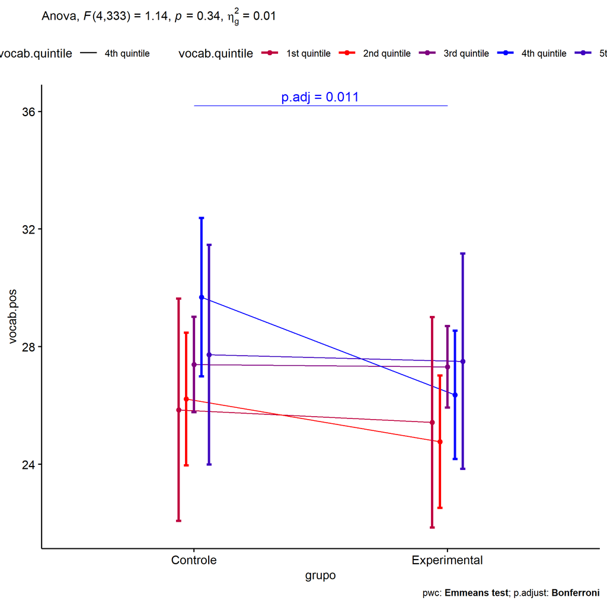

```r
if (!is.null(plots[["grupo"]]))
  plots[["grupo"]] + ggplot2::scale_color_manual(values = color[["vocab.quintile"]])
```

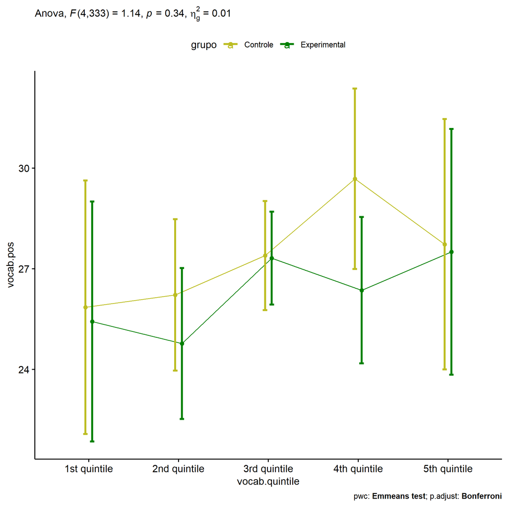

```r
if (!is.null(plots[["vocab.quintile"]]))
  plots[["vocab.quintile"]] + ggplot2::scale_color_manual(values = color[["grupo"]])
```

```r
plots <- twoWayAncovaBoxPlots(
  wdat, "vocab.pos", c("grupo","vocab.quintile"), aov, pwcs, covar = "vocab.pre",
  theme = "classic", color = color[["grupo:vocab.quintile"]],
  subtitle = which(aov$Effect == "grupo:vocab.quintile"))
```

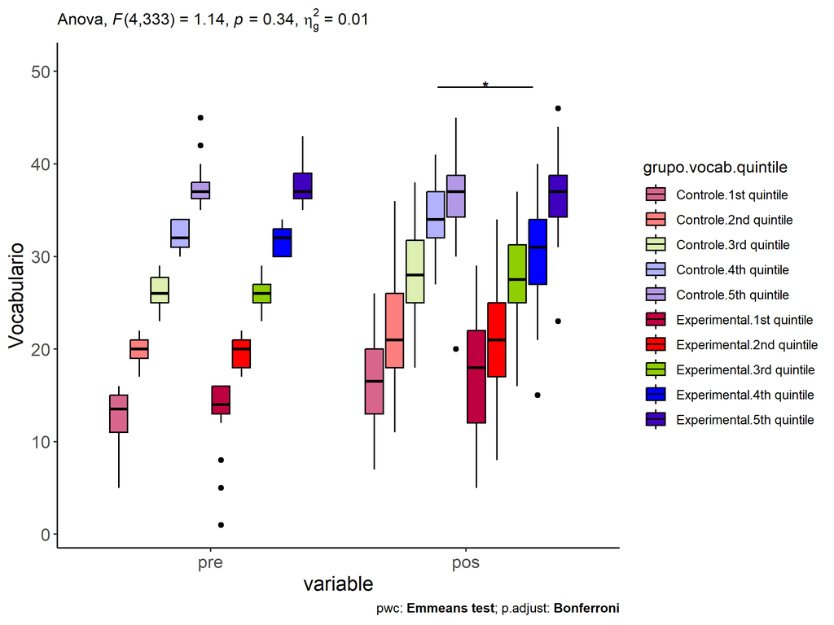

```r
plots[["grupo:vocab.quintile"]] + ggplot2::ylab("Vocabulario") + ggplot2::scale_x_discrete(labels=c('pre', 'pos'))
```

```r
plots <- twoWayAncovaBoxPlots(
  wdat.long, "vocab", c("grupo","vocab.quintile"), aov, pwc.long, pre.post = "time",
  theme = "classic", color = color$prepost)
```

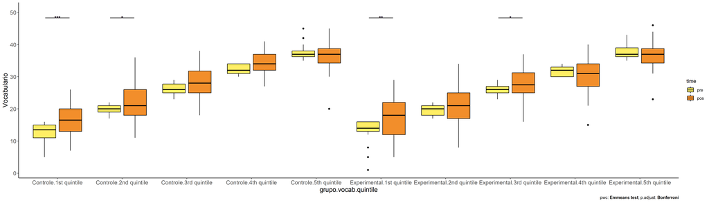

```r
plots[["grupo:vocab.quintile"]] + ggplot2::ylab("Vocabulario")
```

### Checking linearity assumption

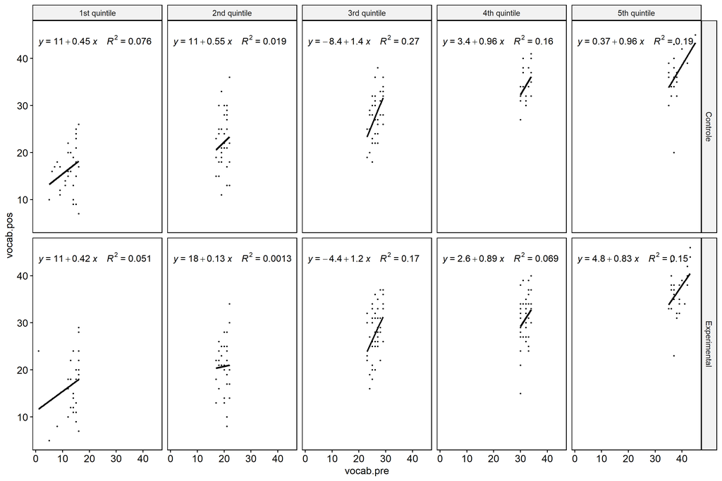

```r
ggscatter(wdat, x = "vocab.pre", y = "vocab.pos", size = 0.5,
          facet.by = c("grupo","vocab.quintile"), add = "reg.line")+
  stat_regline_equation(
    aes(label =  paste(..eq.label.., ..rr.label.., sep = "~~~~"))
  )
```

### Checking normality and homogeneity

```r
res <- augment(lm(vocab.pos ~ vocab.pre + grupo*vocab.quintile, data = wdat))
```

```r
shapiro_test(res$.resid)
```

```
## # A tibble: 1 × 3
##   variable   statistic p.value
##   <chr>          <dbl>   <dbl>
## 1 res$.resid     0.994   0.222
```

```r
levene_test(res, .resid ~ grupo*vocab.quintile)
```

```
## # A tibble: 1 × 4
##     df1   df2 statistic      p
##   <int> <int>     <dbl>  <dbl>
## 1     9   334      1.76 0.0748
```

# Summary of Results

## Descriptive Statistics

```r
df <- get.descriptives(ldat[["grupo"]], c(dv.pre, dv.pos), c("grupo"),
                       include.global = T, symmetry.test = T, normality.test = F)
df <- plyr::rbind.fill(
  df, do.call(plyr::rbind.fill, lapply(lfatores2, FUN = function(f) {
    if (nrow(dat) > 0 && sum(!is.na(unique(dat[[f]]))) > 1)
      get.descriptives(ldat[[paste0("grupo:",f)]], c(dv.pre,dv.pos), c("grupo", f),
                       symmetry.test = T, normality.test = F)
    }))
)
(df <- df[,c(fatores1[fatores1 %in% colnames(df)],"variable",
             colnames(df)[!colnames(df) %in% c(fatores1,"variable")])])
```

```
##           grupo Sexo   Zona Cor.Raca vocab.quintile  variable   n   mean median min max    sd    se    ci   iqr
## 1      Controle <NA>   <NA>     <NA>           <NA> vocab.pre 149 24.302   25.0   5  45 8.687 0.712 1.406 13.00
## 2  Experimental <NA>   <NA>     <NA>           <NA> vocab.pre 194 26.500   27.0   1  43 8.289 0.595 1.174 13.00
## 3          <NA> <NA>   <NA>     <NA>           <NA> vocab.pre 343 25.545   26.0   1  45 8.522 0.460 0.905 13.00
## 4      Controle <NA>   <NA>     <NA>           <NA> vocab.pos 149 26.403   27.0   7  45 8.669 0.710 1.403 14.00
## 5  Experimental <NA>   <NA>     <NA>           <NA> vocab.pos 194 27.067   27.0   5  46 8.345 0.599 1.182 11.75
## 6          <NA> <NA>   <NA>     <NA>           <NA> vocab.pos 343 26.778   27.0   5  46 8.481 0.458 0.901 12.00
## 7      Controle    F   <NA>     <NA>           <NA> vocab.pre  85 25.718   26.0   8  42 8.185 0.888 1.765 14.00
## 8      Controle    M   <NA>     <NA>           <NA> vocab.pre  65 22.646   21.0   5  45 9.147 1.135 2.267 15.00
## 9  Experimental    F   <NA>     <NA>           <NA> vocab.pre  98 26.255   27.0   1  43 8.306 0.839 1.665 12.00
## 10 Experimental    M   <NA>     <NA>           <NA> vocab.pre  96 26.750   27.0   5  43 8.307 0.848 1.683 12.00
## 11     Controle    F   <NA>     <NA>           <NA> vocab.pos  85 27.365   28.0   7  43 8.021 0.870 1.730 12.00
## 12     Controle    M   <NA>     <NA>           <NA> vocab.pos  65 25.046   24.0   9  45 9.321 1.156 2.310 16.00
## 13 Experimental    F   <NA>     <NA>           <NA> vocab.pos  98 27.878   28.0   7  46 7.650 0.773 1.534  9.00
## 14 Experimental    M   <NA>     <NA>           <NA> vocab.pos  96 26.240   26.0   5  44 8.964 0.915 1.816 14.00
```

[output cut: 91 more lines]

| grupo | Sexo | Zona | Cor.Raca | vocab.quintile | variable | n | mean | median | min | max | sd | se | ci | iqr | symmetry | skewness | kurtosis |
| --- | --- | --- | --- | --- | --- | --- | --- | --- | --- | --- | --- | --- | --- | --- | --- | --- | --- |
| Controle |  |  |  |  | vocab.pre | 149 | 24.302 | 25.0 | 5 | 45 | 8.687 | 0.712 | 1.406 | 13.00 | YES | -0.003 | -0.818 |
| Experimental |  |  |  |  | vocab.pre | 194 | 26.500 | 27.0 | 1 | 43 | 8.289 | 0.595 | 1.174 | 13.00 | YES | -0.216 | -0.486 |
|  |  |  |  |  | vocab.pre | 343 | 25.545 | 26.0 | 1 | 45 | 8.522 | 0.460 | 0.905 | 13.00 | YES | -0.131 | -0.656 |
| Controle |  |  |  |  | vocab.pos | 149 | 26.403 | 27.0 | 7 | 45 | 8.669 | 0.710 | 1.403 | 14.00 | YES | -0.141 | -0.902 |
| Experimental |  |  |  |  | vocab.pos | 194 | 27.067 | 27.0 | 5 | 46 | 8.345 | 0.599 | 1.182 | 11.75 | YES | -0.272 | -0.459 |
|  |  |  |  |  | vocab.pos | 343 | 26.778 | 27.0 | 5 | 46 | 8.481 | 0.458 | 0.901 | 12.00 | YES | -0.216 | -0.657 |
| Controle | F |  |  |  | vocab.pre | 85 | 25.718 | 26.0 | 8 | 42 | 8.185 | 0.888 | 1.765 | 14.00 | YES | -0.096 | -0.909 |
| Controle | M |  |  |  | vocab.pre | 65 | 22.646 | 21.0 | 5 | 45 | 9.147 | 1.135 | 2.267 | 15.00 | YES | 0.181 | -0.784 |
| Experimental | F |  |  |  | vocab.pre | 98 | 26.255 | 27.0 | 1 | 43 | 8.306 | 0.839 | 1.665 | 12.00 | YES | -0.162 | -0.344 |
| Experimental | M |  |  |  | vocab.pre | 96 | 26.750 | 27.0 | 5 | 43 | 8.307 | 0.848 | 1.683 | 12.00 | YES | -0.268 | -0.673 |
| Controle | F |  |  |  | vocab.pos | 85 | 27.365 | 28.0 | 7 | 43 | 8.021 | 0.870 | 1.730 | 12.00 | YES | -0.267 | -0.717 |
| Controle | M |  |  |  | vocab.pos | 65 | 25.046 | 24.0 | 9 | 45 | 9.321 | 1.156 | 2.310 | 16.00 | YES | 0.093 | -1.077 |
| Experimental | F |  |  |  | vocab.pos | 98 | 27.878 | 28.0 | 7 | 46 | 7.650 | 0.773 | 1.534 | 9.00 | YES | -0.354 | -0.134 |
| Experimental | M |  |  |  | vocab.pos | 96 | 26.240 | 26.0 | 5 | 44 | 8.964 | 0.915 | 1.816 | 14.00 | YES | -0.144 | -0.753 |
| Controle |  | Rural |  |  | vocab.pre | 75 | 24.707 | 26.0 | 8 | 45 | 8.382 | 0.968 | 1.929 | 13.00 | YES | 0.063 | -0.900 |
| Controle |  | Urbana |  |  | vocab.pre | 49 | 26.041 | 25.0 | 6 | 42 | 8.703 | 1.243 | 2.500 | 14.00 | YES | -0.249 | -0.837 |
| Experimental |  | Rural |  |  | vocab.pre | 91 | 26.495 | 27.0 | 5 | 43 | 8.460 | 0.887 | 1.762 | 11.50 | YES | -0.197 | -0.612 |
| Experimental |  | Urbana |  |  | vocab.pre | 75 | 26.920 | 27.0 | 1 | 43 | 8.228 | 0.950 | 1.893 | 11.50 | YES | -0.313 | -0.076 |
| Controle |  | Rural |  |  | vocab.pos | 75 | 27.413 | 28.0 | 10 | 45 | 8.505 | 0.982 | 1.957 | 13.50 | YES | -0.164 | -0.896 |
| Controle |  | Urbana |  |  | vocab.pos | 49 | 27.082 | 29.0 | 7 | 40 | 8.672 | 1.239 | 2.491 | 13.00 | YES | -0.470 | -0.796 |
| Experimental |  | Rural |  |  | vocab.pos | 91 | 26.692 | 27.0 | 5 | 46 | 8.754 | 0.918 | 1.823 | 12.00 | YES | -0.220 | -0.304 |
| Experimental |  | Urbana |  |  | vocab.pos | 75 | 27.827 | 29.0 | 9 | 44 | 8.125 | 0.938 | 1.869 | 12.00 | YES | -0.369 | -0.662 |
| Controle |  |  | Branca |  | vocab.pre | 22 | 26.273 | 27.0 | 12 | 45 | 8.172 | 1.742 | 3.623 | 11.75 | YES | 0.214 | -0.552 |
| Controle |  |  | Indígena |  | vocab.pre | 8 | 24.250 | 25.5 | 15 | 33 | 6.386 | 2.258 | 5.339 | 5.75 | YES | -0.367 | -1.412 |
| Controle |  |  | Parda |  | vocab.pre | 44 | 22.591 | 21.0 | 9 | 38 | 8.478 | 1.278 | 2.578 | 15.25 | YES | 0.286 | -1.148 |
| Experimental |  |  | Branca |  | vocab.pre | 12 | 26.667 | 27.5 | 15 | 37 | 6.972 | 2.013 | 4.430 | 8.75 | YES | -0.364 | -1.222 |
| Experimental |  |  | Parda |  | vocab.pre | 53 | 24.396 | 25.0 | 1 | 42 | 8.654 | 1.189 | 2.385 | 12.00 | YES | -0.038 | -0.377 |
| Controle |  |  | Branca |  | vocab.pos | 22 | 28.000 | 29.0 | 13 | 45 | 7.910 | 1.686 | 3.507 | 10.00 | YES | 0.109 | -0.601 |
| Controle |  |  | Indígena |  | vocab.pos | 8 | 28.875 | 27.5 | 18 | 38 | 7.717 | 2.728 | 6.452 | 12.50 | YES | 0.011 | -1.784 |
| Controle |  |  | Parda |  | vocab.pos | 44 | 25.545 | 26.0 | 7 | 40 | 9.598 | 1.447 | 2.918 | 16.50 | YES | -0.082 | -1.330 |
| Experimental |  |  | Branca |  | vocab.pos | 12 | 24.000 | 23.0 | 9 | 37 | 7.160 | 2.067 | 4.550 | 6.75 | YES | -0.110 | -0.238 |
| Experimental |  |  | Parda |  | vocab.pos | 53 | 25.396 | 26.0 | 7 | 40 | 7.510 | 1.032 | 2.070 | 9.00 | YES | -0.224 | -0.334 |
| Controle |  |  |  | 1st quintile | vocab.pre | 32 | 12.500 | 13.5 | 5 | 16 | 3.059 | 0.541 | 1.103 | 4.00 | NO | -0.894 | -0.314 |
| Controle |  |  |  | 2nd quintile | vocab.pre | 35 | 19.686 | 20.0 | 17 | 22 | 1.510 | 0.255 | 0.519 | 2.00 | YES | -0.123 | -1.132 |
| Controle |  |  |  | 3rd quintile | vocab.pre | 38 | 26.342 | 26.0 | 23 | 29 | 1.790 | 0.290 | 0.588 | 2.75 | YES | 0.017 | -1.036 |
| Controle |  |  |  | 4th quintile | vocab.pre | 23 | 32.261 | 32.0 | 30 | 34 | 1.544 | 0.322 | 0.668 | 3.00 | YES | -0.135 | -1.558 |
| Controle |  |  |  | 5th quintile | vocab.pre | 22 | 37.545 | 37.0 | 35 | 45 | 2.345 | 0.500 | 1.040 | 1.75 | NO | 1.564 | 2.562 |
| Experimental |  |  |  | 1st quintile | vocab.pre | 30 | 13.533 | 14.0 | 1 | 16 | 3.401 | 0.621 | 1.270 | 3.00 | NO | -2.219 | 4.794 |
| Experimental |  |  |  | 2nd quintile | vocab.pre | 34 | 19.824 | 20.0 | 17 | 22 | 1.642 | 0.282 | 0.573 | 3.00 | YES | -0.244 | -1.302 |
| Experimental |  |  |  | 3rd quintile | vocab.pre | 52 | 26.115 | 26.0 | 23 | 29 | 1.688 | 0.234 | 0.470 | 2.00 | YES | -0.010 | -0.831 |
| Experimental |  |  |  | 4th quintile | vocab.pre | 44 | 31.750 | 32.0 | 30 | 34 | 1.512 | 0.228 | 0.460 | 3.00 | YES | 0.101 | -1.505 |
| Experimental |  |  |  | 5th quintile | vocab.pre | 34 | 38.206 | 37.0 | 35 | 43 | 2.346 | 0.402 | 0.818 | 2.75 | NO | 0.758 | -0.790 |
| Controle |  |  |  | 1st quintile | vocab.pos | 32 | 16.594 | 16.5 | 7 | 26 | 4.983 | 0.881 | 1.797 | 7.00 | YES | -0.002 | -0.897 |
| Controle |  |  |  | 2nd quintile | vocab.pos | 35 | 22.057 | 21.0 | 11 | 36 | 6.097 | 1.031 | 2.094 | 8.00 | YES | 0.223 | -0.692 |
| Controle |  |  |  | 3rd quintile | vocab.pos | 38 | 27.947 | 28.0 | 18 | 38 | 4.793 | 0.777 | 1.575 | 6.75 | YES | -0.064 | -0.617 |
| Controle |  |  |  | 4th quintile | vocab.pos | 23 | 34.435 | 34.0 | 27 | 41 | 3.678 | 0.767 | 1.591 | 5.00 | YES | 0.082 | -1.027 |
| Controle |  |  |  | 5th quintile | vocab.pos | 22 | 36.227 | 37.0 | 20 | 45 | 5.089 | 1.085 | 2.256 | 4.50 | NO | -1.173 | 2.490 |
| Experimental |  |  |  | 1st quintile | vocab.pos | 30 | 16.900 | 18.0 | 5 | 29 | 6.326 | 1.155 | 2.362 | 10.00 | YES | 0.013 | -1.022 |
| Experimental |  |  |  | 2nd quintile | vocab.pos | 34 | 20.706 | 21.0 | 8 | 34 | 5.808 | 0.996 | 2.026 | 8.00 | YES | -0.083 | -0.429 |
| Experimental |  |  |  | 3rd quintile | vocab.pos | 52 | 27.712 | 27.5 | 16 | 37 | 5.058 | 0.701 | 1.408 | 6.25 | YES | -0.113 | -0.624 |
| Experimental |  |  |  | 4th quintile | vocab.pos | 44 | 30.750 | 31.0 | 15 | 40 | 5.109 | 0.770 | 1.553 | 7.00 | NO | -0.535 | 0.468 |
| Experimental |  |  |  | 5th quintile | vocab.pos | 34 | 36.471 | 37.0 | 23 | 46 | 5.017 | 0.860 | 1.750 | 4.50 | NO | -0.677 | 1.025 |

## ANCOVA Table Comparison

```r
df <- do.call(plyr::rbind.fill, laov)
(df <- df[!duplicated(df$Effect),])
```

```
##                  Effect DFn DFd       F        p p<.05      ges DFn' DFd'         F'       p' p<.05'     ges'
## 1                 grupo   1 340   4.221 4.10e-02     * 0.012000    1  346   2.276000 1.32e-01        7.00e-03
## 2             vocab.pre   1 340 652.429 4.35e-81     * 0.657000    1  346 498.152000 5.43e-69      * 5.90e-01
## 4            grupo:Sexo   1 339   3.995 4.60e-02     * 0.012000    1  344   1.844000 1.75e-01        5.00e-03
## 5                  Sexo   1 339   4.075 4.40e-02     * 0.012000    1  344   6.644000 1.00e-02      * 1.90e-02
## 8            grupo:Zona   1 285   3.392 6.70e-02       0.012000    1  290   2.139000 1.45e-01        7.00e-03
## 10                 Zona   1 285   0.056 8.13e-01       0.000196    1  290   0.000256 9.87e-01        8.84e-07
## 11             Cor.Raca   2 133   1.585 2.09e-01       0.023000    2  133   1.585000 2.09e-01        2.30e-02
## 13       grupo:Cor.Raca   1 133   1.611 2.07e-01       0.012000    1  133   1.611000 2.07e-01        1.20e-02
## 16 grupo:vocab.quintile   4 333   1.138 3.39e-01       0.013000    4  338   1.040000 3.87e-01        1.20e-02
## 18       vocab.quintile   4 333   0.828 5.08e-01       0.010000    4  338   0.669000 6.14e-01        8.00e-03
```

|  | Effect | DFn | DFd | F | p | p<.05 | ges | DFn’ | DFd’ | F’ | p’ | p<.05’ | ges’ |
| --- | --- | --- | --- | --- | --- | --- | --- | --- | --- | --- | --- | --- | --- |
| 1 | grupo | 1 | 340 | 4.221 | 0.041 | * | 0.012 | 1 | 346 | 2.276 | 0.132 |  | 0.007 |
| 2 | vocab.pre | 1 | 340 | 652.429 | 0.000 | * | 0.657 | 1 | 346 | 498.152 | 0.000 | * | 0.590 |
| 4 | grupo:Sexo | 1 | 339 | 3.995 | 0.046 | * | 0.012 | 1 | 344 | 1.844 | 0.175 |  | 0.005 |
| 5 | Sexo | 1 | 339 | 4.075 | 0.044 | * | 0.012 | 1 | 344 | 6.644 | 0.010 | * | 0.019 |
| 8 | grupo:Zona | 1 | 285 | 3.392 | 0.067 |  | 0.012 | 1 | 290 | 2.139 | 0.145 |  | 0.007 |
| 10 | Zona | 1 | 285 | 0.056 | 0.813 |  | 0.000 | 1 | 290 | 0.000 | 0.987 |  | 0.000 |
| 11 | Cor.Raca | 2 | 133 | 1.585 | 0.209 |  | 0.023 | 2 | 133 | 1.585 | 0.209 |  | 0.023 |
| 13 | grupo:Cor.Raca | 1 | 133 | 1.611 | 0.207 |  | 0.012 | 1 | 133 | 1.611 | 0.207 |  | 0.012 |
| 16 | grupo:vocab.quintile | 4 | 333 | 1.138 | 0.339 |  | 0.013 | 4 | 338 | 1.040 | 0.387 |  | 0.012 |
| 18 | vocab.quintile | 4 | 333 | 0.828 | 0.508 |  | 0.010 | 4 | 338 | 0.669 | 0.614 |  | 0.008 |

## PairWise Table Comparison

```r
df <- do.call(plyr::rbind.fill, lpwc)
df <- df[,c(names(lfatores), names(df)[!names(df) %in% c(names(lfatores),"term",".y.")])]
```

| grupo | Sexo | Zona | Cor.Raca | vocab.quintile | group1 | group2 | df | statistic | p | p.adj | p.adj.signif | df’ | statistic’ | p’ | p.adj’ | p.adj.signif’ |
| --- | --- | --- | --- | --- | --- | --- | --- | --- | --- | --- | --- | --- | --- | --- | --- | --- |
| Controle |  |  |  |  | pre | pos | 682 | -2.139 | 0.033 | 0.033 | * | 694 | -1.678 | 0.094 | 0.094 | ns |
| Experimental |  |  |  |  | pre | pos | 682 | -0.659 | 0.510 | 0.510 | ns | 694 | -0.346 | 0.729 | 0.729 | ns |
|  |  |  |  |  | Controle | Experimental | 340 | 2.055 | 0.041 | 0.041 | * | 346 | 1.509 | 0.132 | 0.132 | ns |
| Controle | F |  |  |  | pre | pos | 680 | -1.271 | 0.204 | 0.204 | ns | 690 | -1.257 | 0.209 | 0.209 | ns |
| Controle | M |  |  |  | pre | pos | 680 | -1.620 | 0.106 | 0.106 | ns | 690 | -1.123 | 0.262 | 0.262 | ns |
| Controle |  |  |  |  | F | M | 339 | -0.193 | 0.847 | 0.847 | ns | 344 | 0.659 | 0.510 | 0.510 | ns |
| Experimental | F |  |  |  | pre | pos | 680 | -1.345 | 0.179 | 0.179 | ns | 690 | -1.215 | 0.225 | 0.225 | ns |
| Experimental | M |  |  |  | pre | pos | 680 | 0.419 | 0.676 | 0.676 | ns | 690 | 0.728 | 0.467 | 0.467 | ns |
| Experimental |  |  |  |  | F | M | 339 | 2.835 | 0.005 | 0.005 | ** | 344 | 2.836 | 0.005 | 0.005 | ** |
|  | F |  |  |  | Controle | Experimental | 339 | -0.107 | 0.915 | 0.915 | ns | 344 | 0.083 | 0.934 | 0.934 | ns |
|  | M |  |  |  | Controle | Experimental | 339 | 2.601 | 0.010 | 0.010 | ** | 344 | 1.921 | 0.056 | 0.056 | ns |
| Controle |  |  |  |  | Rural | Urbana | 285 | 1.557 | 0.121 | 0.121 | ns | 290 | 1.123 | 0.262 | 0.262 | ns |
| Controle |  | Rural |  |  | pre | pos | 572 | -1.957 | 0.051 | 0.051 | ns | 582 | -1.475 | 0.141 | 0.141 | ns |
| Controle |  | Urbana |  |  | pre | pos | 572 | -0.608 | 0.543 | 0.543 | ns | 582 | -0.408 | 0.683 | 0.683 | ns |
| Experimental |  |  |  |  | Rural | Urbana | 285 | -1.010 | 0.313 | 0.313 | ns | 290 | -0.937 | 0.350 | 0.350 | ns |
| Experimental |  | Rural |  |  | pre | pos | 572 | -0.158 | 0.875 | 0.875 | ns | 582 | 0.034 | 0.973 | 0.973 | ns |
| Experimental |  | Urbana |  |  | pre | pos | 572 | -0.656 | 0.512 | 0.512 | ns | 582 | -0.520 | 0.603 | 0.603 | ns |
|  |  | Rural |  |  | Controle | Experimental | 285 | 2.807 | 0.005 | 0.005 | ** | 290 | 2.015 | 0.045 | 0.045 | * |
|  |  | Urbana |  |  | Controle | Experimental | 285 | -0.025 | 0.980 | 0.980 | ns | 290 | -0.205 | 0.838 | 0.838 | ns |
| Controle |  |  | Branca |  | pre | pos | 268 | -0.691 | 0.490 | 0.490 | ns | 268 | -0.691 | 0.490 | 0.490 | ns |
| Controle |  |  | Indígena |  | pre | pos | 268 | -1.116 | 0.265 | 0.265 | ns | 268 | -1.116 | 0.265 | 0.265 | ns |
| Controle |  |  |  |  | Branca | Indígena | 133 | -1.120 | 0.265 | 0.794 | ns | 133 | -1.120 | 0.265 | 0.794 | ns |
| Controle |  |  |  |  | Branca | Parda | 133 | -0.282 | 0.779 | 1.000 | ns | 133 | -0.282 | 0.779 | 1.000 | ns |
| Controle |  |  |  |  | Indígena | Parda | 133 | 1.011 | 0.314 | 0.942 | ns | 133 | 1.011 | 0.314 | 0.942 | ns |
| Controle |  |  | Parda |  | pre | pos | 268 | -1.673 | 0.096 | 0.096 | ns | 268 | -1.673 | 0.096 | 0.096 | ns |
| Experimental |  |  | Branca |  | pre | pos | 268 | 0.788 | 0.431 | 0.431 | ns | 268 | 0.788 | 0.431 | 0.431 | ns |
| Experimental |  |  | Indígena |  | pre | pos |  |  |  |  |  |  |  |  |  |  |
| Experimental |  |  |  |  | Branca | Indígena |  |  |  |  |  |  |  |  |  |  |
| Experimental |  |  |  |  | Branca | Parda | 133 | -1.867 | 0.064 | 0.064 | ns | 133 | -1.867 | 0.064 | 0.064 | ns |
| Experimental |  |  |  |  | Indígena | Parda |  |  |  |  |  |  |  |  |  |  |
| Experimental |  |  | Parda |  | pre | pos | 268 | -0.621 | 0.535 | 0.535 | ns | 268 | -0.621 | 0.535 | 0.535 | ns |
|  |  |  | Branca |  | Controle | Experimental | 133 | 2.278 | 0.024 | 0.024 | * | 133 | 2.278 | 0.024 | 0.024 | * |
|  |  |  | Indígena |  | Controle | Experimental |  |  |  |  |  |  |  |  |  |  |
|  |  |  | Parda |  | Controle | Experimental | 133 | 1.433 | 0.154 | 0.154 | ns | 133 | 1.433 | 0.154 | 0.154 | ns |
| Controle |  |  |  | 1st quintile | pre | pos | 668 | -4.080 | 0.000 | 0.000 | **** | 678 | -3.770 | 0.000 | 0.000 | *** |
| Controle |  |  |  | 2nd quintile | pre | pos | 668 | -2.472 | 0.014 | 0.014 | * | 678 | -2.284 | 0.023 | 0.023 | * |
| Controle |  |  |  | 3rd quintile | pre | pos | 668 | -1.743 | 0.082 | 0.082 | ns | 678 | -1.173 | 0.241 | 0.241 | ns |
| Controle |  |  |  | 4th quintile | pre | pos | 668 | -1.837 | 0.067 | 0.067 | ns | 678 | -1.697 | 0.090 | 0.090 | ns |
| Controle |  |  |  | 5th quintile | pre | pos | 668 | 1.089 | 0.276 | 0.276 | ns | 678 | 1.969 | 0.049 | 0.049 | * |
| Controle |  |  |  |  | 1st quintile | 2nd quintile | 333 | -0.238 | 0.812 | 1.000 | ns | 338 | -0.188 | 0.851 | 1.000 | ns |
| Controle |  |  |  |  | 1st quintile | 3rd quintile | 333 | -0.708 | 0.479 | 1.000 | ns | 338 | -0.411 | 0.681 | 1.000 | ns |
| Controle |  |  |  |  | 1st quintile | 4th quintile | 333 | -1.311 | 0.191 | 1.000 | ns | 338 | -1.158 | 0.248 | 1.000 | ns |
| Controle |  |  |  |  | 1st quintile | 5th quintile | 333 | -0.528 | 0.598 | 1.000 | ns | 338 | -0.138 | 0.890 | 1.000 | ns |
| Controle |  |  |  |  | 2nd quintile | 3rd quintile | 333 | -0.798 | 0.426 | 1.000 | ns | 338 | -0.407 | 0.684 | 1.000 | ns |
| Controle |  |  |  |  | 2nd quintile | 4th quintile | 333 | -1.628 | 0.105 | 1.000 | ns | 338 | -1.450 | 0.148 | 1.000 | ns |
| Controle |  |  |  |  | 2nd quintile | 5th quintile | 333 | -0.558 | 0.577 | 1.000 | ns | 338 | -0.073 | 0.942 | 1.000 | ns |
| Controle |  |  |  |  | 3rd quintile | 4th quintile | 333 | -1.486 | 0.138 | 1.000 | ns | 338 | -1.610 | 0.108 | 1.000 | ns |
| Controle |  |  |  |  | 3rd quintile | 5th quintile | 333 | -0.169 | 0.866 | 1.000 | ns | 338 | 0.200 | 0.842 | 1.000 | ns |
| Controle |  |  |  |  | 4th quintile | 5th quintile | 333 | 1.180 | 0.239 | 1.000 | ns | 338 | 1.746 | 0.082 | 0.817 | ns |
| Experimental |  |  |  | 1st quintile | pre | pos | 668 | -3.249 | 0.001 | 0.001 | ** | 678 | -3.002 | 0.003 | 0.003 | ** |
| Experimental |  |  |  | 2nd quintile | pre | pos | 668 | -0.906 | 0.365 | 0.365 | ns | 678 | -0.838 | 0.403 | 0.403 | ns |
| Experimental |  |  |  | 3rd quintile | pre | pos | 668 | -2.028 | 0.043 | 0.043 | * | 678 | -1.174 | 0.241 | 0.241 | ns |
| Experimental |  |  |  | 4th quintile | pre | pos | 668 | 1.169 | 0.243 | 0.243 | ns | 678 | 1.080 | 0.281 | 0.281 | ns |
| Experimental |  |  |  | 5th quintile | pre | pos | 668 | 1.783 | 0.075 | 0.075 | ns | 678 | 2.229 | 0.026 | 0.026 | * |
| Experimental |  |  |  |  | 1st quintile | 2nd quintile | 333 | 0.434 | 0.665 | 1.000 | ns | 338 | 0.420 | 0.675 | 1.000 | ns |
| Experimental |  |  |  |  | 1st quintile | 3rd quintile | 333 | -0.942 | 0.347 | 1.000 | ns | 338 | -0.542 | 0.588 | 1.000 | ns |
| Experimental |  |  |  |  | 1st quintile | 4th quintile | 333 | -0.351 | 0.725 | 1.000 | ns | 338 | -0.280 | 0.780 | 1.000 | ns |
| Experimental |  |  |  |  | 1st quintile | 5th quintile | 333 | -0.601 | 0.548 | 1.000 | ns | 338 | -0.355 | 0.723 | 1.000 | ns |
| Experimental |  |  |  |  | 2nd quintile | 3rd quintile | 333 | -1.839 | 0.067 | 0.667 | ns | 338 | -1.247 | 0.213 | 1.000 | ns |
| Experimental |  |  |  |  | 2nd quintile | 4th quintile | 333 | -0.821 | 0.412 | 1.000 | ns | 338 | -0.712 | 0.477 | 1.000 | ns |
| Experimental |  |  |  |  | 2nd quintile | 5th quintile | 333 | -1.015 | 0.311 | 1.000 | ns | 338 | -0.693 | 0.489 | 1.000 | ns |
| Experimental |  |  |  |  | 3rd quintile | 4th quintile | 333 | 0.754 | 0.451 | 1.000 | ns | 338 | 0.269 | 0.788 | 1.000 | ns |
| Experimental |  |  |  |  | 3rd quintile | 5th quintile | 333 | -0.097 | 0.923 | 1.000 | ns | 338 | -0.073 | 0.941 | 1.000 | ns |
| Experimental |  |  |  |  | 4th quintile | 5th quintile | 333 | -0.801 | 0.424 | 1.000 | ns | 338 | -0.338 | 0.736 | 1.000 | ns |
|  |  |  |  | 1st quintile | Controle | Experimental | 333 | 0.330 | 0.741 | 0.741 | ns | 338 | 0.305 | 0.761 | 0.761 | ns |
|  |  |  |  | 2nd quintile | Controle | Experimental | 333 | 1.191 | 0.235 | 0.235 | ns | 338 | 1.082 | 0.280 | 0.280 | ns |
|  |  |  |  | 3rd quintile | Controle | Experimental | 333 | 0.070 | 0.945 | 0.945 | ns | 338 | 0.187 | 0.852 | 0.852 | ns |
|  |  |  |  | 4th quintile | Controle | Experimental | 333 | 2.552 | 0.011 | 0.011 | * | 338 | 2.315 | 0.021 | 0.021 | * |
|  |  |  |  | 5th quintile | Controle | Experimental | 333 | 0.162 | 0.871 | 0.871 | ns | 338 | -0.248 | 0.804 | 0.804 | ns |

## EMMS Table Comparison

```r
df <- do.call(plyr::rbind.fill, lemms)
df[["N-N'"]] <- df[["N"]] - df[["N'"]]
df <- df[,c(names(lfatores), names(df)[!names(df) %in% names(lfatores)])]
```

| grupo | Sexo | Zona | Cor.Raca | vocab.quintile | N | M (pre) | SE (pre) | M (unadj) | SE (unadj) | M (adj) | SE (adj) | N’ | M (pre)’ | SE (pre)’ | M (unadj)’ | SE (unadj)’ | M (adj)’ | SE (adj)’ | N-N’ |
| --- | --- | --- | --- | --- | --- | --- | --- | --- | --- | --- | --- | --- | --- | --- | --- | --- | --- | --- | --- |
| Controle |  |  |  |  | 149 | 24.302 | 0.712 | 26.403 | 0.710 | 27.413 | 0.409 | 152 | 24.480 | 0.710 | 26.132 | 0.716 | 27.033 | 0.452 | -3 |
| Experimental |  |  |  |  | 194 | 26.500 | 0.595 | 27.067 | 0.599 | 26.291 | 0.358 | 197 | 26.518 | 0.590 | 26.817 | 0.608 | 26.122 | 0.397 | -3 |
| Controle | F |  |  |  | 85 | 25.718 | 0.888 | 27.365 | 0.870 | 27.252 | 0.543 | 85 | 25.718 | 0.888 | 27.365 | 0.870 | 27.296 | 0.597 | 0 |
| Controle | M |  |  |  | 65 | 22.646 | 1.135 | 25.046 | 1.156 | 27.413 | 0.628 | 67 | 22.910 | 1.131 | 24.567 | 1.171 | 26.700 | 0.679 | -2 |
| Experimental | F |  |  |  | 98 | 26.255 | 0.839 | 27.878 | 0.773 | 27.331 | 0.506 | 99 | 26.202 | 0.832 | 27.677 | 0.791 | 27.229 | 0.554 | -1 |
| Experimental | M |  |  |  | 96 | 26.750 | 0.848 | 26.240 | 0.915 | 25.294 | 0.512 | 98 | 26.837 | 0.841 | 25.949 | 0.922 | 25.003 | 0.558 | -2 |
| Controle |  | Rural |  |  | 75 | 24.707 | 0.968 | 27.413 | 0.982 | 28.529 | 0.577 | 77 | 25.065 | 0.976 | 27.104 | 0.984 | 27.968 | 0.639 | -2 |
| Controle |  | Urbana |  |  | 49 | 26.041 | 1.243 | 27.082 | 1.239 | 27.102 | 0.712 | 50 | 25.980 | 1.220 | 26.680 | 1.279 | 26.826 | 0.792 | -1 |
| Experimental |  | Rural |  |  | 91 | 26.495 | 0.887 | 26.692 | 0.918 | 26.340 | 0.523 | 92 | 26.630 | 0.888 | 26.587 | 0.914 | 26.222 | 0.584 | -1 |
| Experimental |  | Urbana |  |  | 75 | 26.920 | 0.950 | 27.827 | 0.938 | 27.125 | 0.576 | 76 | 26.842 | 0.941 | 27.566 | 0.962 | 27.035 | 0.643 | -1 |
| Controle |  |  | Branca |  | 22 | 26.273 | 1.742 | 28.000 | 1.686 | 26.482 | 1.128 | 22 | 26.273 | 1.742 | 28.000 | 1.686 | 26.482 | 1.128 | 0 |
| Controle |  |  | Indígena |  | 8 | 24.250 | 2.258 | 28.875 | 2.728 | 28.921 | 1.861 | 8 | 24.250 | 2.258 | 28.875 | 2.728 | 28.921 | 1.861 | 0 |
| Controle |  |  | Parda |  | 44 | 22.591 | 1.278 | 25.545 | 1.447 | 26.874 | 0.799 | 44 | 22.591 | 1.278 | 25.545 | 1.447 | 26.874 | 0.799 | 0 |
| Experimental |  |  | Branca |  | 12 | 26.667 | 2.013 | 24.000 | 2.067 | 22.178 | 1.525 | 12 | 26.667 | 2.013 | 24.000 | 2.067 | 22.178 | 1.525 | 0 |
| Experimental |  |  | Parda |  | 53 | 24.396 | 1.189 | 25.396 | 1.032 | 25.329 | 0.723 | 53 | 24.396 | 1.189 | 25.396 | 1.032 | 25.329 | 0.723 | 0 |
| Controle |  |  |  | 1st quintile | 32 | 12.500 | 0.541 | 16.594 | 0.881 | 25.852 | 1.922 | 32 | 12.500 | 0.541 | 16.594 | 0.881 | 25.991 | 2.109 | 0 |
| Controle |  |  |  | 2nd quintile | 35 | 19.686 | 0.255 | 22.057 | 1.031 | 26.221 | 1.147 | 35 | 19.686 | 0.255 | 22.057 | 1.031 | 26.312 | 1.264 | 0 |
| Controle |  |  |  | 3rd quintile | 38 | 26.342 | 0.290 | 27.947 | 0.777 | 27.392 | 0.826 | 39 | 26.256 | 0.296 | 27.410 | 0.928 | 26.962 | 0.896 | -1 |
| Controle |  |  |  | 4th quintile | 23 | 32.261 | 0.322 | 34.435 | 0.767 | 29.682 | 1.368 | 23 | 32.261 | 0.322 | 34.435 | 0.767 | 29.689 | 1.495 | 0 |
| Controle |  |  |  | 5th quintile | 22 | 37.545 | 0.500 | 36.227 | 1.085 | 27.728 | 1.897 | 23 | 37.652 | 0.489 | 35.130 | 1.509 | 26.527 | 2.065 | -1 |
| Experimental |  |  |  | 1st quintile | 30 | 13.533 | 0.621 | 16.900 | 1.155 | 25.426 | 1.818 | 30 | 13.533 | 0.621 | 16.900 | 1.155 | 25.558 | 1.997 | 0 |
| Experimental |  |  |  | 2nd quintile | 34 | 19.824 | 0.282 | 20.706 | 0.996 | 24.772 | 1.144 | 34 | 19.824 | 0.282 | 20.706 | 0.996 | 24.862 | 1.262 | 0 |
| Experimental |  |  |  | 3rd quintile | 52 | 26.115 | 0.234 | 27.712 | 0.701 | 27.316 | 0.704 | 54 | 26.093 | 0.235 | 27.074 | 0.815 | 26.743 | 0.760 | -2 |
| Experimental |  |  |  | 4th quintile | 44 | 31.750 | 0.228 | 30.750 | 0.770 | 26.360 | 1.110 | 44 | 31.750 | 0.228 | 30.750 | 0.770 | 26.370 | 1.208 | 0 |
| Experimental |  |  |  | 5th quintile | 34 | 38.206 | 0.402 | 36.471 | 0.860 | 27.503 | 1.862 | 35 | 38.229 | 0.391 | 35.914 | 1.004 | 26.898 | 2.022 | -1 |